# FHB data matrix codebook

### VPD.L6.CD.1

No. d (mean VPD < 0.6 kPa), 20 d pre-anthesis to anthesis

#### Distribution

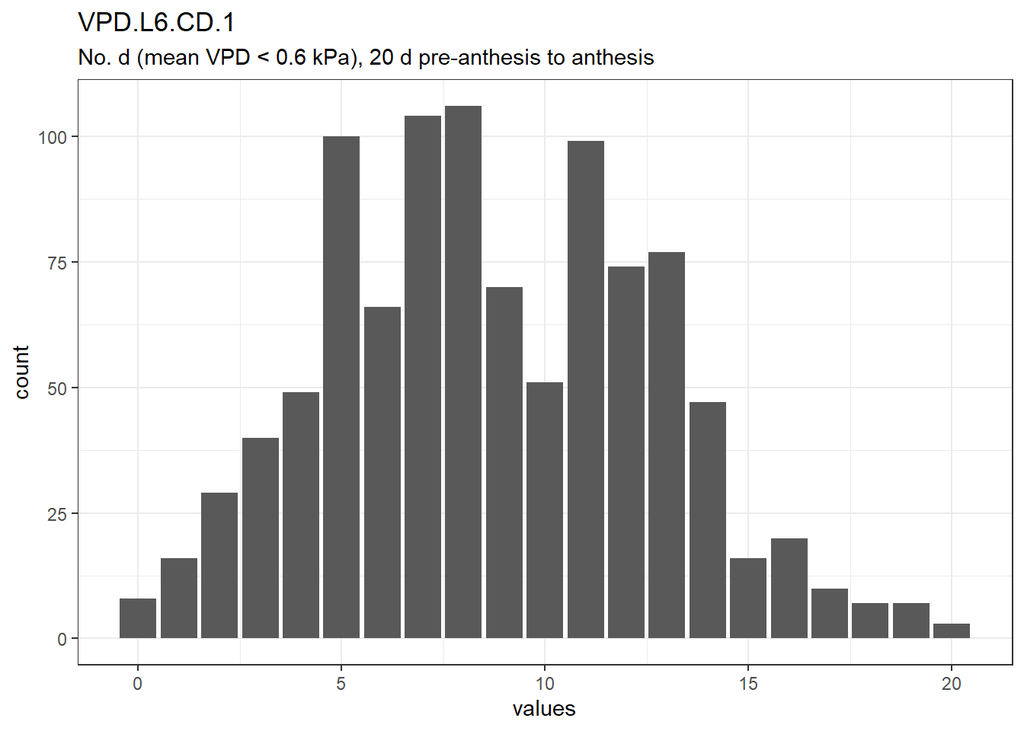

Distribution of values for VPD.L6.CD.1

0 missing values.

#### Summary statistics

| name | label | data_type | n_missing | complete_rate | min | median | max | mean | sd | hist |
| --- | --- | --- | --- | --- | --- | --- | --- | --- | --- | --- |
| VPD.L6.CD.1 | No. d (mean VPD < 0.6 kPa), 20 d pre-anthesis to anthesis | numeric | 0 | 1 | 0 | 8 | 20 | 8.695696 | 3.969762 | ▃▇▆▃▁ |

### VPD.L6.CD.2

No. d (mean VPD < 0.6 kPa), 40 d pre-anthesis to anthesis

#### Distribution

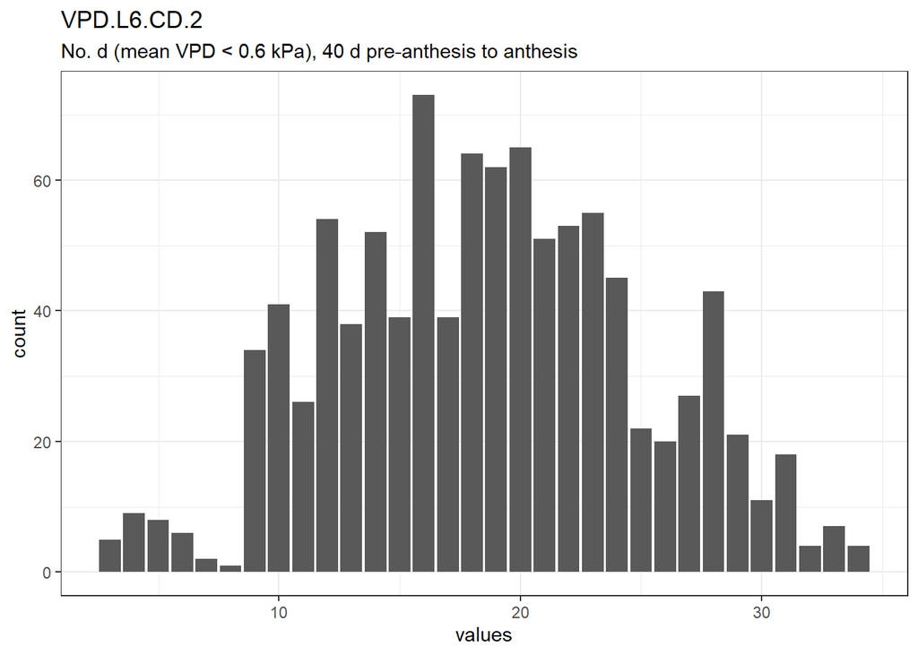

Distribution of values for VPD.L6.CD.2

0 missing values.

#### Summary statistics

| name | label | data_type | n_missing | complete_rate | min | median | max | mean | sd | hist |
| --- | --- | --- | --- | --- | --- | --- | --- | --- | --- | --- |
| VPD.L6.CD.2 | No. d (mean VPD < 0.6 kPa), 40 d pre-anthesis to anthesis | numeric | 0 | 1 | 3 | 19 | 34 | 18.66266 | 6.337796 | ▂▆▇▅▂ |

### VPD.L6.CD.3

No. d (mean VPD < 0.6 kPa), anthesis to 20 d post-anthesis

#### Distribution

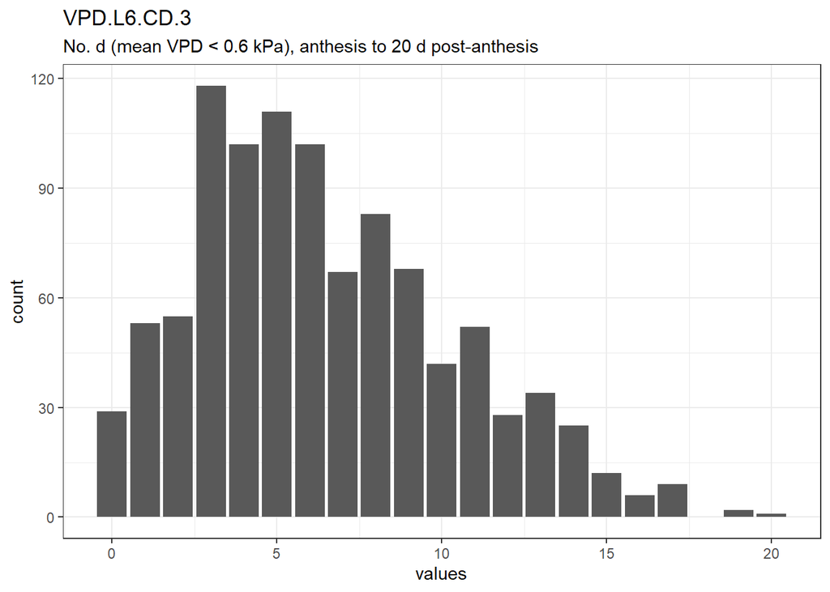

Distribution of values for VPD.L6.CD.3

0 missing values.

#### Summary statistics

| name | label | data_type | n_missing | complete_rate | min | median | max | mean | sd | hist |
| --- | --- | --- | --- | --- | --- | --- | --- | --- | --- | --- |
| VPD.L6.CD.3 | No. d (mean VPD < 0.6 kPa), anthesis to 20 d post-anthesis | numeric | 0 | 1 | 0 | 6 | 20 | 6.45045 | 3.887096 | ▇▇▅▂▁ |

### T.MINMAXDIFF.1

Mean daily T range (°C), 20 d pre-anthesis to anthesis

#### Distribution

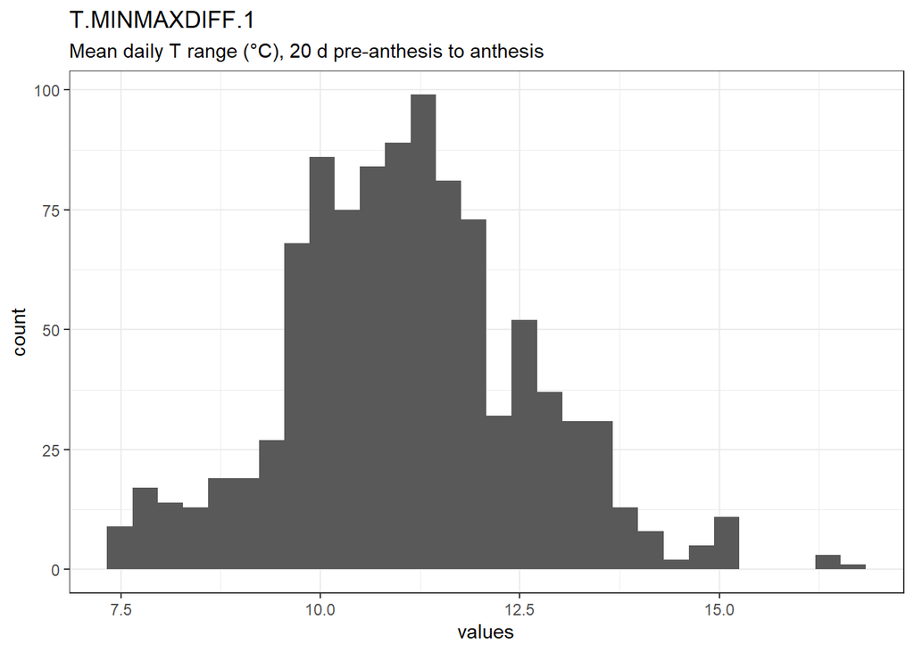

Distribution of values for T.MINMAXDIFF.1

0 missing values.

#### Summary statistics

| name | label | data_type | n_missing | complete_rate | min | median | max | mean | sd | hist |
| --- | --- | --- | --- | --- | --- | --- | --- | --- | --- | --- |
| T.MINMAXDIFF.1 | Mean daily T range (°C), 20 d pre-anthesis to anthesis | numeric | 0 | 1 | 7.5 | 11 | 17 | 11.1043 | 1.511622 | ▂▇▆▂▁ |

### T.MINMAXDIFF.2

Mean daily T range (°C), 20 d pre-anthesis to 10 d post-anthesis

#### Distribution

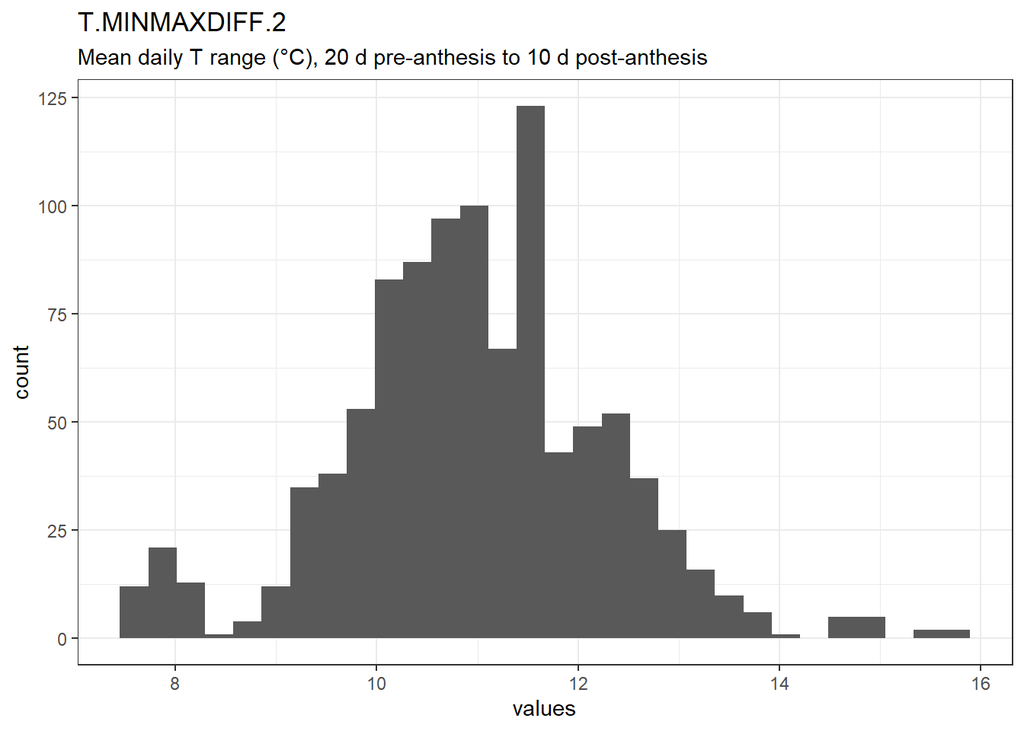

Distribution of values for T.MINMAXDIFF.2

0 missing values.

#### Summary statistics

| name | label | data_type | n_missing | complete_rate | min | median | max | mean | sd | hist |
| --- | --- | --- | --- | --- | --- | --- | --- | --- | --- | --- |
| T.MINMAXDIFF.2 | Mean daily T range (°C), 20 d pre-anthesis to 10 d post-anthesis | numeric | 0 | 1 | 7.6 | 11 | 16 | 10.97497 | 1.311568 | ▂▇▇▂▁ |

### RH.MINMAXDIFF.1

Mean daily RH range (%), 20 d to 10 d pre-anthesis

#### Distribution

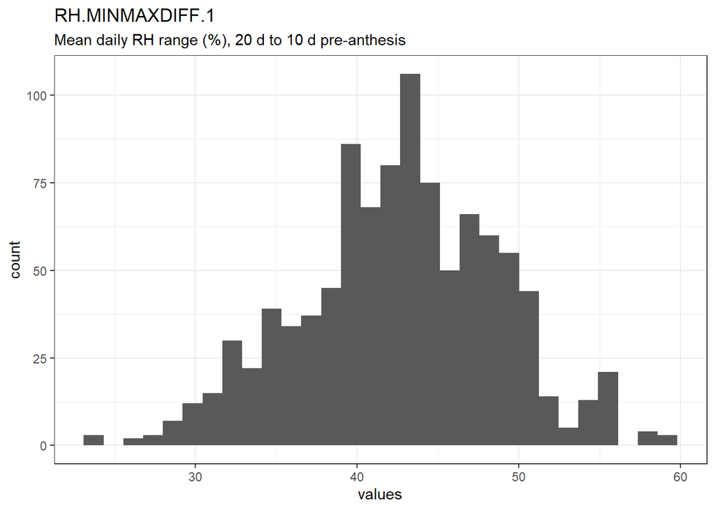

Distribution of values for RH.MINMAXDIFF.1

0 missing values.

#### Summary statistics

| name | label | data_type | n_missing | complete_rate | min | median | max | mean | sd | hist |
| --- | --- | --- | --- | --- | --- | --- | --- | --- | --- | --- |
| RH.MINMAXDIFF.1 | Mean daily RH range (%), 20 d to 10 d pre-anthesis | numeric | 0 | 1 | 24 | 43 | 59 | 42.58384 | 6.140004 | ▁▃▇▅▁ |

### RH.MINMAXDIFF.2

Mean daily RH range (%), 30 d pre-anthesis to anthesis

#### Distribution

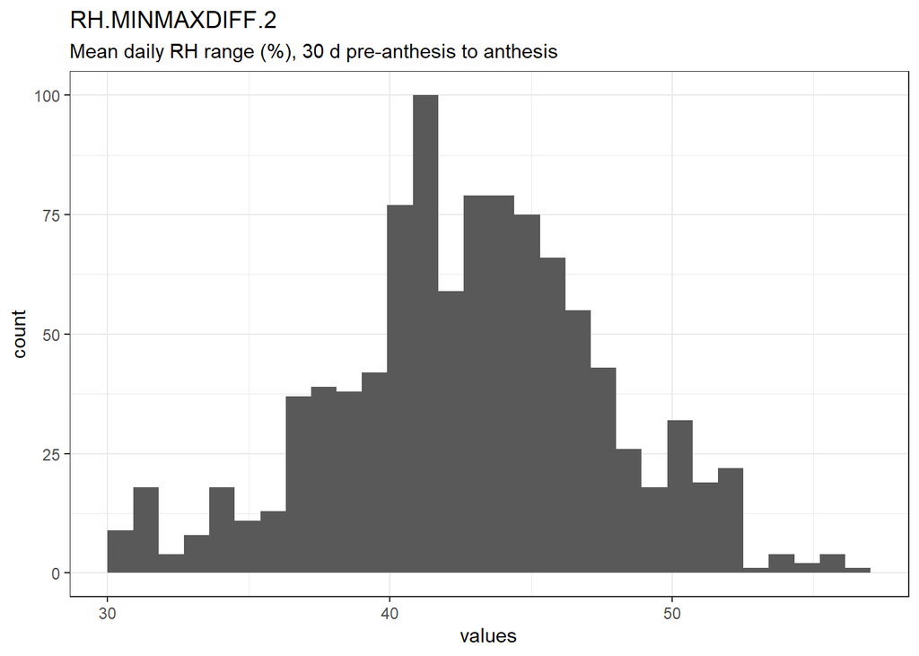

Distribution of values for RH.MINMAXDIFF.2

0 missing values.

#### Summary statistics

| name | label | data_type | n_missing | complete_rate | min | median | max | mean | sd | hist |
| --- | --- | --- | --- | --- | --- | --- | --- | --- | --- | --- |
| RH.MINMAXDIFF.2 | Mean daily RH range (%), 30 d pre-anthesis to anthesis | numeric | 0 | 1 | 30 | 43 | 57 | 42.7912 | 4.803392 | ▁▅▇▃▁ |

### RH.MINMAXDIFF.3

Mean daily RH range (%), 30 d pre-anthesis to 10 d post-anthesis

#### Distribution

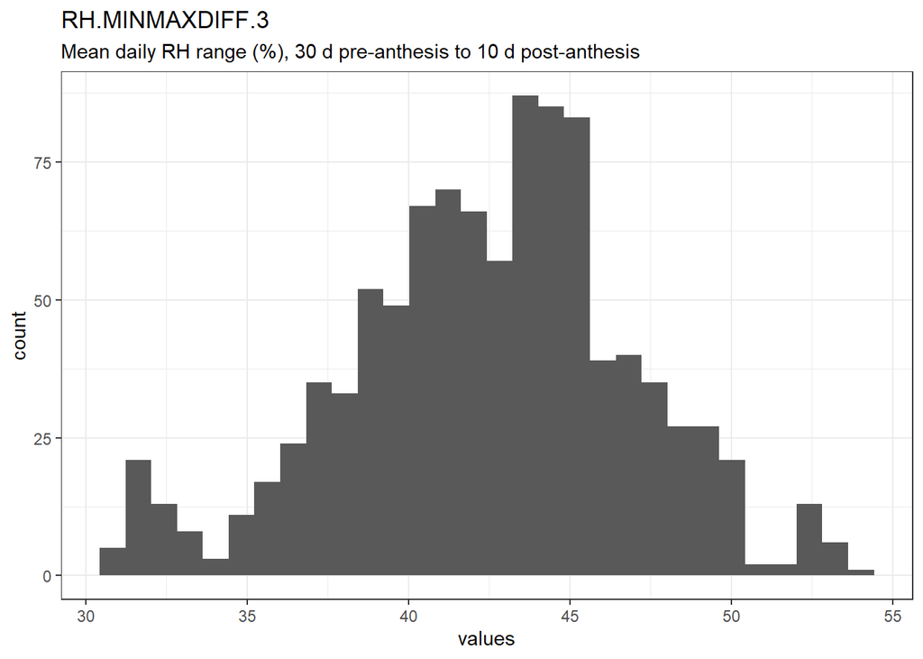

Distribution of values for RH.MINMAXDIFF.3

0 missing values.

#### Summary statistics

| name | label | data_type | n_missing | complete_rate | min | median | max | mean | sd | hist |
| --- | --- | --- | --- | --- | --- | --- | --- | --- | --- | --- |
| RH.MINMAXDIFF.3 | Mean daily RH range (%), 30 d pre-anthesis to 10 d post-anthesis | numeric | 0 | 1 | 31 | 43 | 54 | 42.45464 | 4.470727 | ▁▅▇▅▁ |

### P.MINMAXDIFF.1

Mean daily P range (hPa), 60 d to 50 d pre-anthesis

#### Distribution

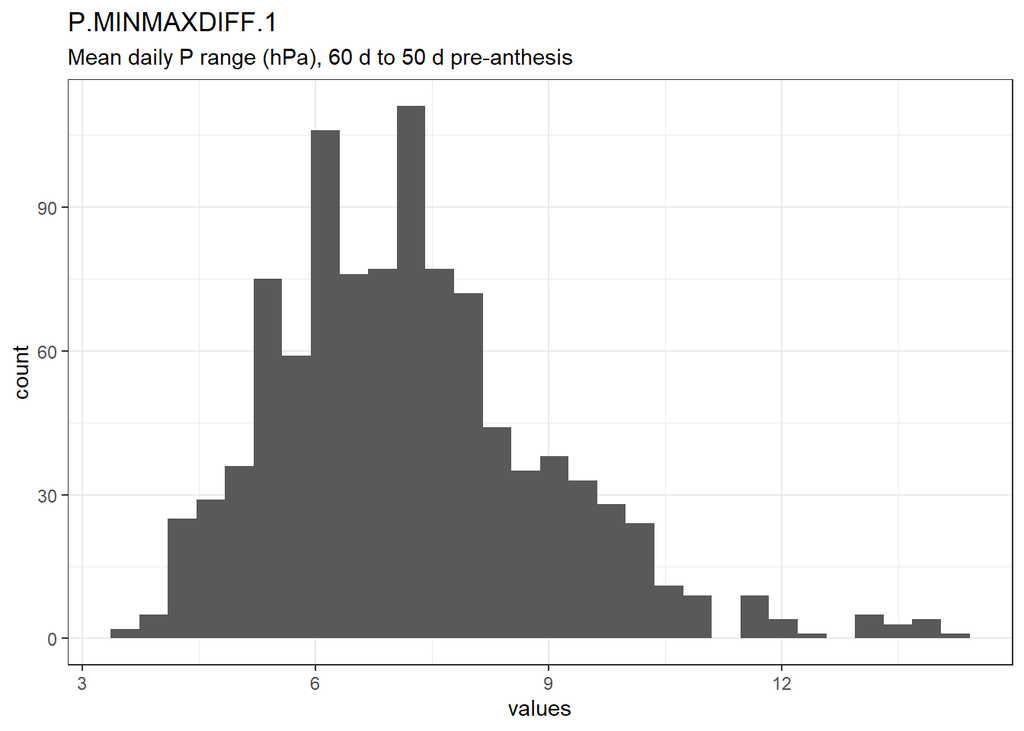

Distribution of values for P.MINMAXDIFF.1

0 missing values.

#### Summary statistics

| name | label | data_type | n_missing | complete_rate | min | median | max | mean | sd | hist |
| --- | --- | --- | --- | --- | --- | --- | --- | --- | --- | --- |
| P.MINMAXDIFF.1 | Mean daily P range (hPa), 60 d to 50 d pre-anthesis | numeric | 0 | 1 | 3.5 | 7.1 | 14 | 7.236813 | 1.776437 | ▃▇▃▁▁ |

### D.MINMAXDIFF.1

Mean daily D range (°C), 30 d pre-anthesis to anthesis

#### Distribution

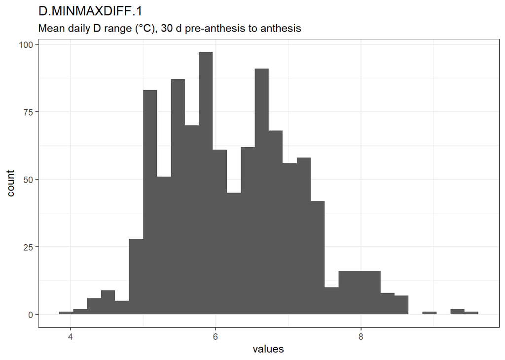

Distribution of values for D.MINMAXDIFF.1

0 missing values.

#### Summary statistics

| name | label | data_type | n_missing | complete_rate | min | median | max | mean | sd | hist |
| --- | --- | --- | --- | --- | --- | --- | --- | --- | --- | --- |
| D.MINMAXDIFF.1 | Mean daily D range (°C), 30 d pre-anthesis to anthesis | numeric | 0 | 1 | 3.9 | 6.1 | 9.5 | 6.233727 | 0.9083914 | ▂▇▇▂▁ |

### D.MINMAXDIFF.2

Mean daily D range (°C), 40 d to 5 d pre-anthesis

#### Distribution

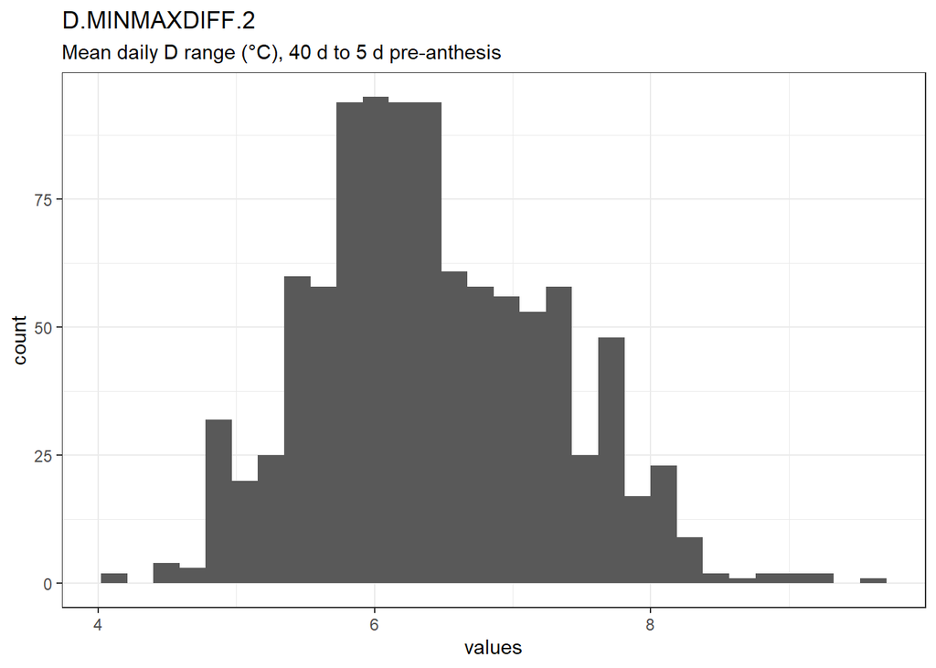

Distribution of values for D.MINMAXDIFF.2

0 missing values.

#### Summary statistics

| name | label | data_type | n_missing | complete_rate | min | median | max | mean | sd | hist |
| --- | --- | --- | --- | --- | --- | --- | --- | --- | --- | --- |
| D.MINMAXDIFF.2 | Mean daily D range (°C), 40 d to 5 d pre-anthesis | numeric | 0 | 1 | 4.1 | 6.3 | 9.6 | 6.422303 | 0.8595308 | ▁▇▇▂▁ |

### D.MINMAXDIFF.3

Mean daily D range (°C), 20 d pre-anthesis to 10 d post-anthesis

#### Distribution

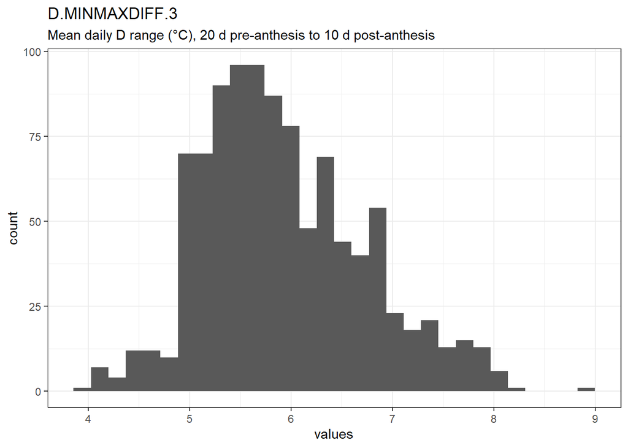

Distribution of values for D.MINMAXDIFF.3

0 missing values.

#### Summary statistics

| name | label | data_type | n_missing | complete_rate | min | median | max | mean | sd | hist |
| --- | --- | --- | --- | --- | --- | --- | --- | --- | --- | --- |
| D.MINMAXDIFF.3 | Mean daily D range (°C), 20 d pre-anthesis to 10 d post-anthesis | numeric | 0 | 1 | 3.9 | 5.8 | 8.9 | 5.930883 | 0.7960515 | ▁▇▅▂▁ |

### VPD.MINMAXDIFF.1

Mean daily VPD range (kPa), 10 d pre-anthesis to anthesis

#### Distribution

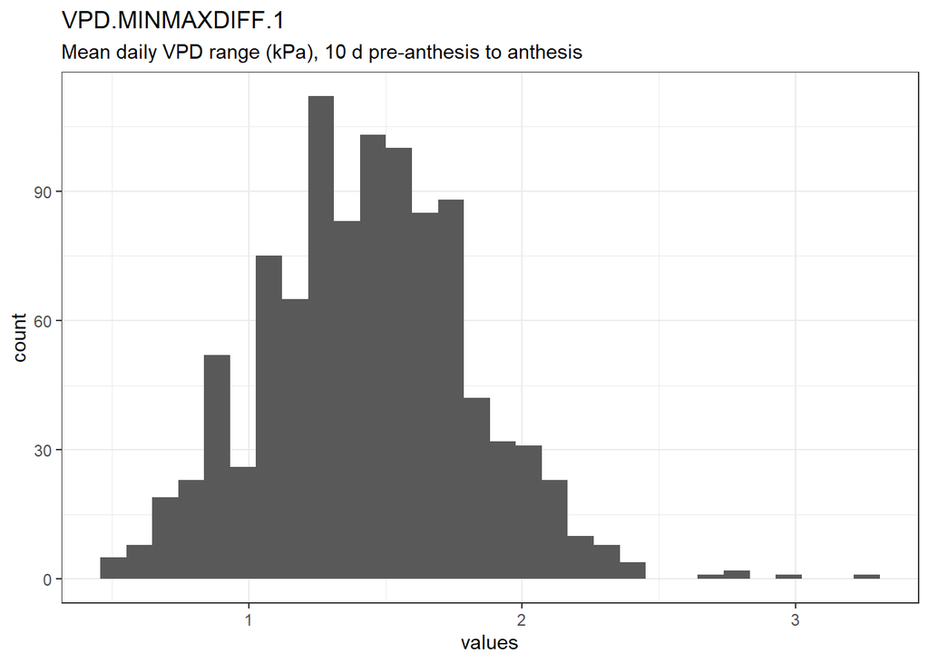

Distribution of values for VPD.MINMAXDIFF.1

0 missing values.

#### Summary statistics

| name | label | data_type | n_missing | complete_rate | min | median | max | mean | sd | hist |
| --- | --- | --- | --- | --- | --- | --- | --- | --- | --- | --- |
| VPD.MINMAXDIFF.1 | Mean daily VPD range (kPa), 10 d pre-anthesis to anthesis | numeric | 0 | 1 | 0.5 | 1.4 | 3.3 | 1.436847 | 0.3824671 | ▂▇▅▁▁ |

### VPD.MINMAXDIFF.2

Mean daily VPD range (kPa), 40 d pre-anthesis to anthesis

#### Distribution

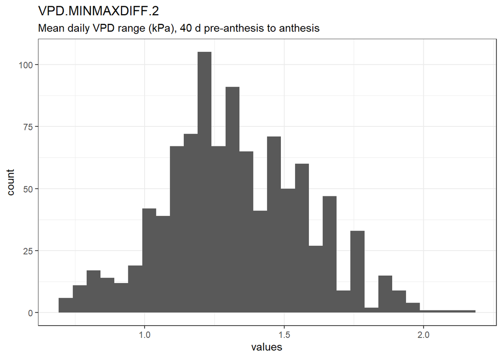

Distribution of values for VPD.MINMAXDIFF.2

0 missing values.

#### Summary statistics

| name | label | data_type | n_missing | complete_rate | min | median | max | mean | sd | hist |
| --- | --- | --- | --- | --- | --- | --- | --- | --- | --- | --- |
| VPD.MINMAXDIFF.2 | Mean daily VPD range (kPa), 40 d pre-anthesis to anthesis | numeric | 0 | 1 | 0.72 | 1.3 | 2.2 | 1.324197 | 0.254469 | ▂▇▇▃▁ |

### VPD.MINMAXDIFF.3

Mean daily VPD range (kPa), 10 d pre-anthesis to 10 d post-anthesis

#### Distribution

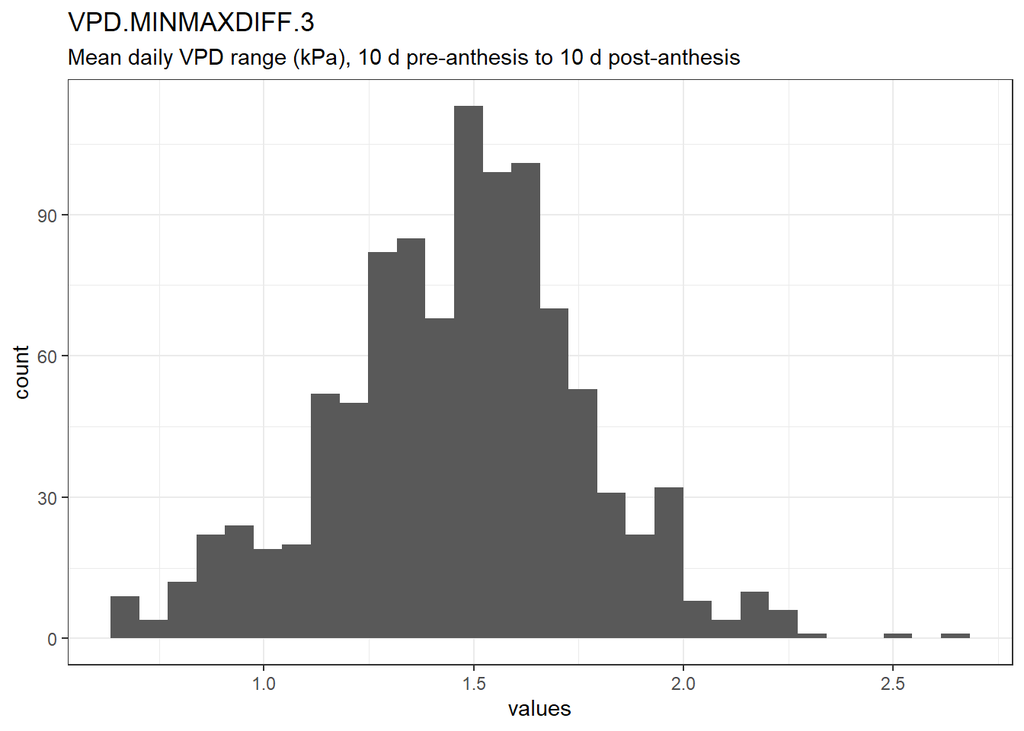

Distribution of values for VPD.MINMAXDIFF.3

0 missing values.

#### Summary statistics

| name | label | data_type | n_missing | complete_rate | min | median | max | mean | sd | hist |
| --- | --- | --- | --- | --- | --- | --- | --- | --- | --- | --- |
| VPD.MINMAXDIFF.3 | Mean daily VPD range (kPa), 10 d pre-anthesis to 10 d post-anthesis | numeric | 0 | 1 | 0.67 | 1.5 | 2.6 | 1.46531 | 0.3012468 | ▂▆▇▂▁ |

### TDD.MINMAXDIFF.1

Mean daily TDD range (°C), 30 d pre-anthesis to anthesis

#### Distribution

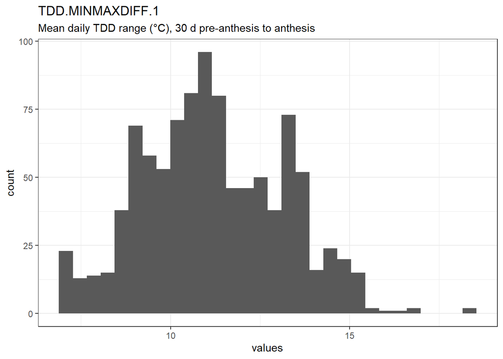

Distribution of values for TDD.MINMAXDIFF.1

0 missing values.

#### Summary statistics

| name | label | data_type | n_missing | complete_rate | min | median | max | mean | sd | hist |
| --- | --- | --- | --- | --- | --- | --- | --- | --- | --- | --- |
| TDD.MINMAXDIFF.1 | Mean daily TDD range (°C), 30 d pre-anthesis to anthesis | numeric | 0 | 1 | 7.1 | 11 | 18 | 11.18781 | 1.972002 | ▃▇▆▂▁ |

### TDD.MINMAXDIFF.2

Mean daily TDD range (°C), 40 d pre-anthesis to anthesis

#### Distribution

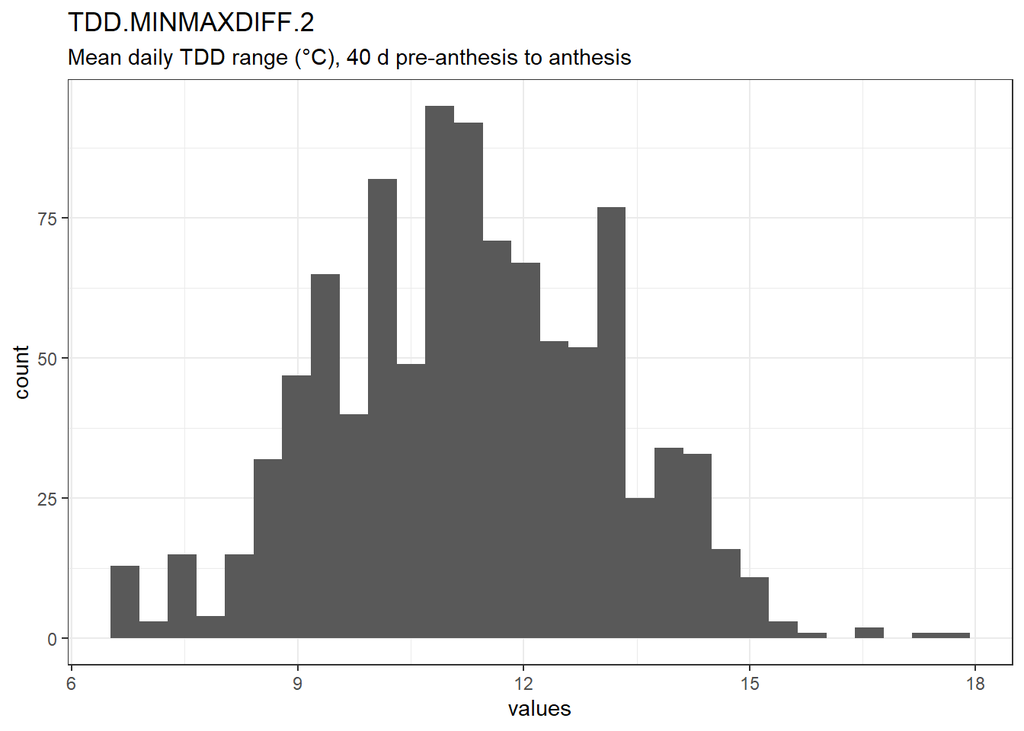

Distribution of values for TDD.MINMAXDIFF.2

0 missing values.

#### Summary statistics

| name | label | data_type | n_missing | complete_rate | min | median | max | mean | sd | hist |
| --- | --- | --- | --- | --- | --- | --- | --- | --- | --- | --- |
| TDD.MINMAXDIFF.2 | Mean daily TDD range (°C), 40 d pre-anthesis to anthesis | numeric | 0 | 1 | 6.7 | 11 | 18 | 11.30062 | 1.845435 | ▂▇▇▃▁ |

### TDD.MINMAXDIFF.3

Mean daily TDD range (°C), 30 d pre-anthesis to 10 d post-anthesis

#### Distribution

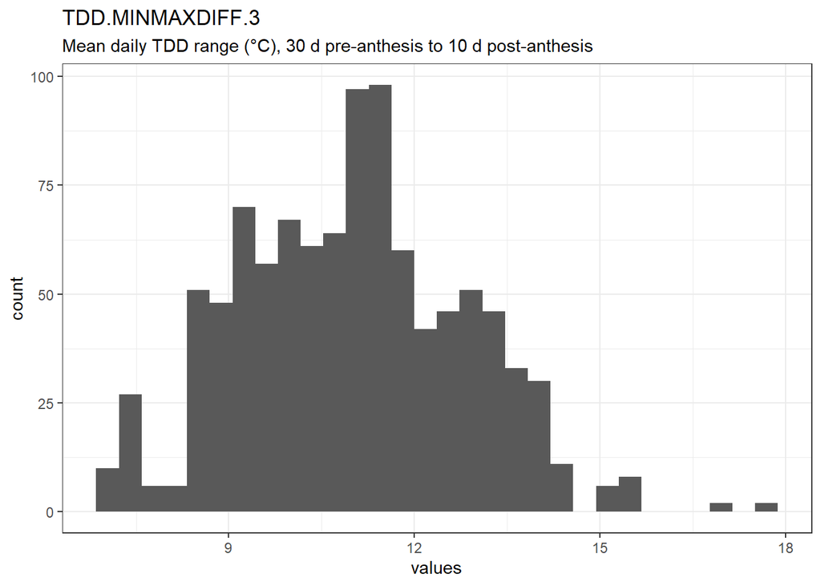

Distribution of values for TDD.MINMAXDIFF.3

0 missing values.

#### Summary statistics

| name | label | data_type | n_missing | complete_rate | min | median | max | mean | sd | hist |
| --- | --- | --- | --- | --- | --- | --- | --- | --- | --- | --- |
| TDD.MINMAXDIFF.3 | Mean daily TDD range (°C), 30 d pre-anthesis to 10 d post-anthesis | numeric | 0 | 1 | 7 | 11 | 18 | 10.99119 | 1.812983 | ▃▇▆▂▁ |

### T.SD.1

Mean(per day sd(hourly T)), 20 d pre-anthesis to anthesis

#### Distribution

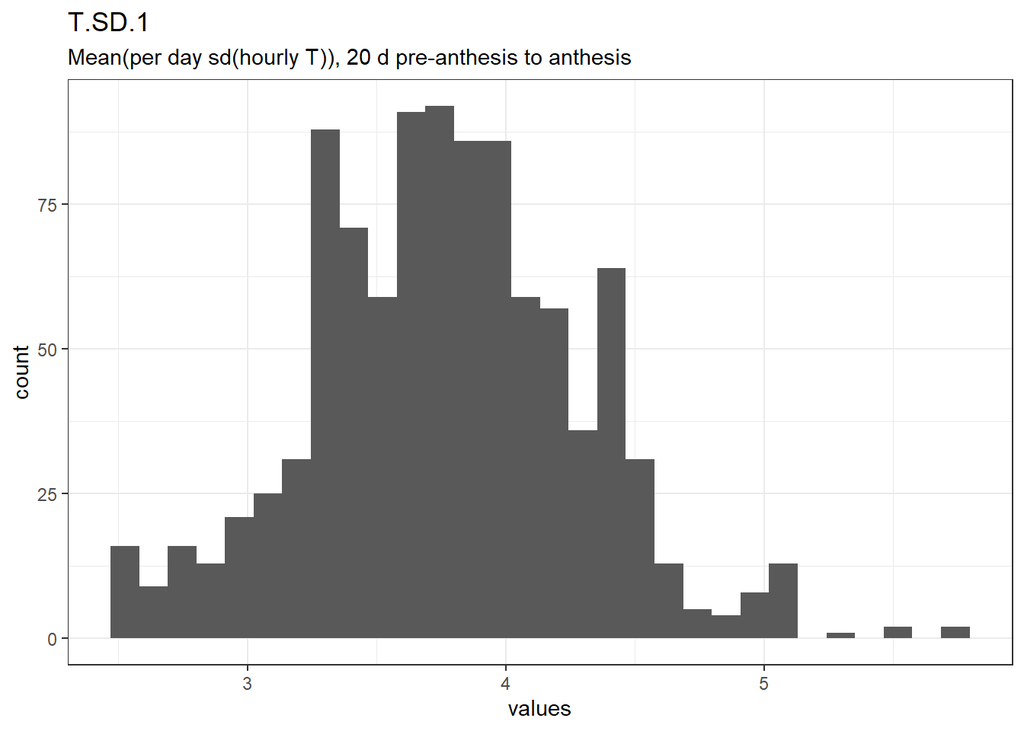

Distribution of values for T.SD.1

0 missing values.

#### Summary statistics

| name | label | data_type | n_missing | complete_rate | min | median | max | mean | sd | hist |
| --- | --- | --- | --- | --- | --- | --- | --- | --- | --- | --- |
| T.SD.1 | Mean(per day sd(hourly T)), 20 d pre-anthesis to anthesis | numeric | 0 | 1 | 2.5 | 3.8 | 5.7 | 3.767714 | 0.5248732 | ▂▇▆▂▁ |

### T.SD.2

Mean(per day sd(hourly T)), anthesis to 10 d post-anthesis

#### Distribution

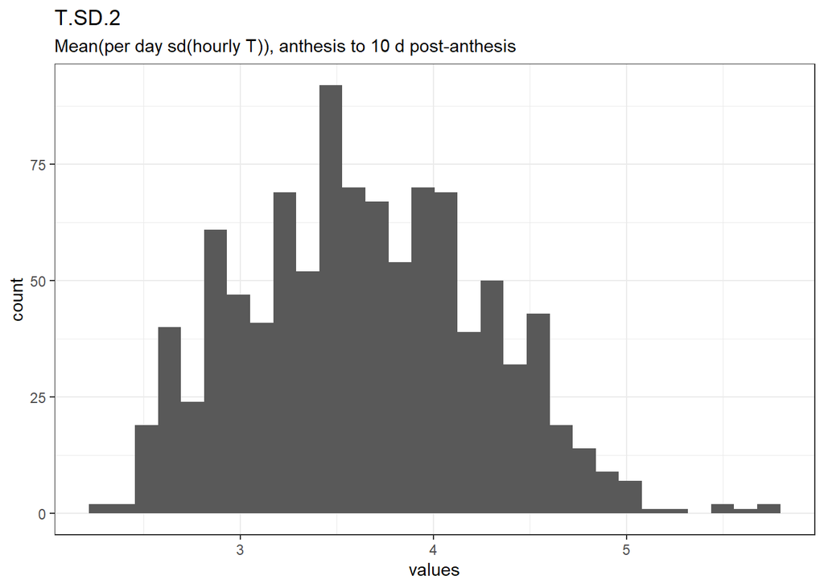

Distribution of values for T.SD.2

0 missing values.

#### Summary statistics

| name | label | data_type | n_missing | complete_rate | min | median | max | mean | sd | hist |
| --- | --- | --- | --- | --- | --- | --- | --- | --- | --- | --- |
| T.SD.2 | Mean(per day sd(hourly T)), anthesis to 10 d post-anthesis | numeric | 0 | 1 | 2.3 | 3.6 | 5.7 | 3.645631 | 0.6121297 | ▃▇▇▃▁ |

### T.SD.3

Mean(per day sd(hourly T)), 20 d pre-anthesis to 10 d post-anthesis

#### Distribution

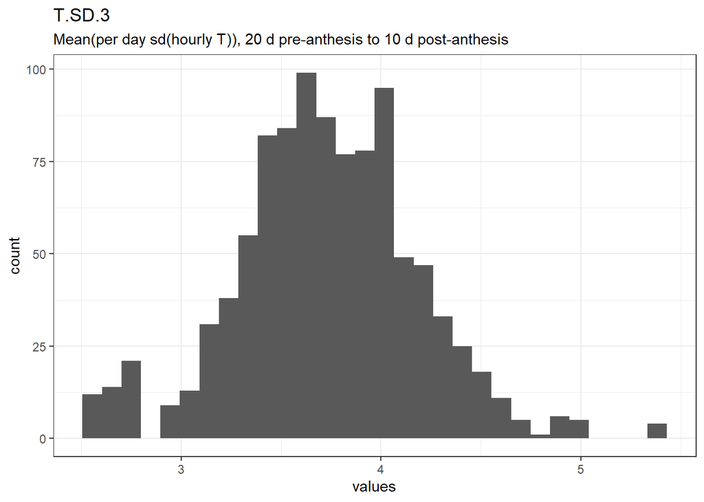

Distribution of values for T.SD.3

0 missing values.

#### Summary statistics

| name | label | data_type | n_missing | complete_rate | min | median | max | mean | sd | hist |
| --- | --- | --- | --- | --- | --- | --- | --- | --- | --- | --- |
| T.SD.3 | Mean(per day sd(hourly T)), 20 d pre-anthesis to 10 d post-anthesis | numeric | 0 | 1 | 2.6 | 3.7 | 5.4 | 3.7313 | 0.4583515 | ▂▇▇▂▁ |

### D.SD.1

Mean(per day sd(hourly D)), 30 d pre-anthesis to anthesis

#### Distribution

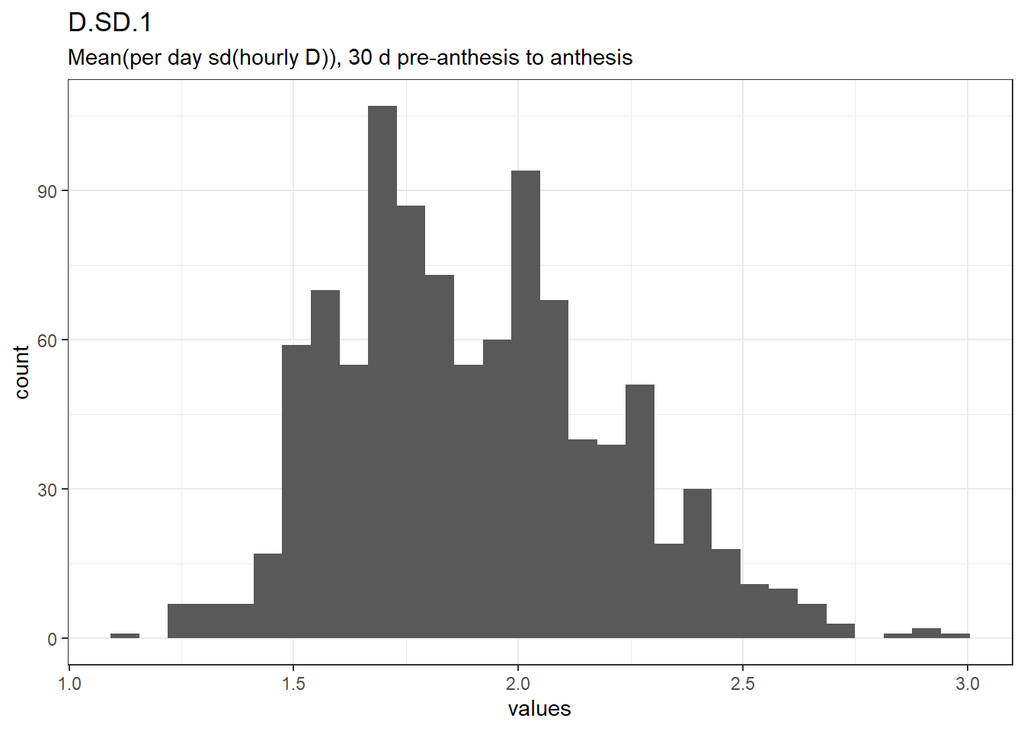

Distribution of values for D.SD.1

0 missing values.

#### Summary statistics

| name | label | data_type | n_missing | complete_rate | min | median | max | mean | sd | hist |
| --- | --- | --- | --- | --- | --- | --- | --- | --- | --- | --- |
| D.SD.1 | Mean(per day sd(hourly D)), 30 d pre-anthesis to anthesis | numeric | 0 | 1 | 1.1 | 1.9 | 3 | 1.904082 | 0.3022062 | ▁▇▆▂▁ |

### D.SD.2

Mean(per day sd(hourly D)), 40 d to 10 d pre-anthesis

#### Distribution

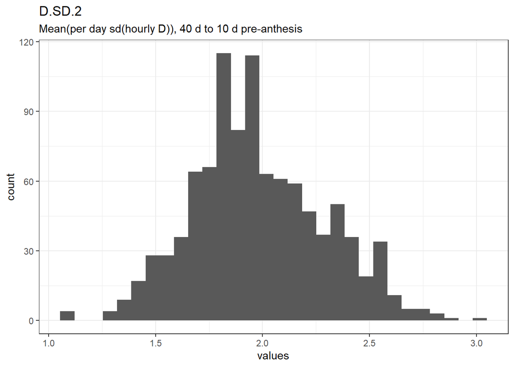

Distribution of values for D.SD.2

0 missing values.

#### Summary statistics

| name | label | data_type | n_missing | complete_rate | min | median | max | mean | sd | hist |
| --- | --- | --- | --- | --- | --- | --- | --- | --- | --- | --- |
| D.SD.2 | Mean(per day sd(hourly D)), 40 d to 10 d pre-anthesis | numeric | 0 | 1 | 1.1 | 1.9 | 3 | 1.980334 | 0.3089891 | ▁▆▇▃▁ |

### D.SD.3

Mean(per day sd(hourly D)), 40 d pre-anthesis to 10 d post-anthesis

#### Distribution

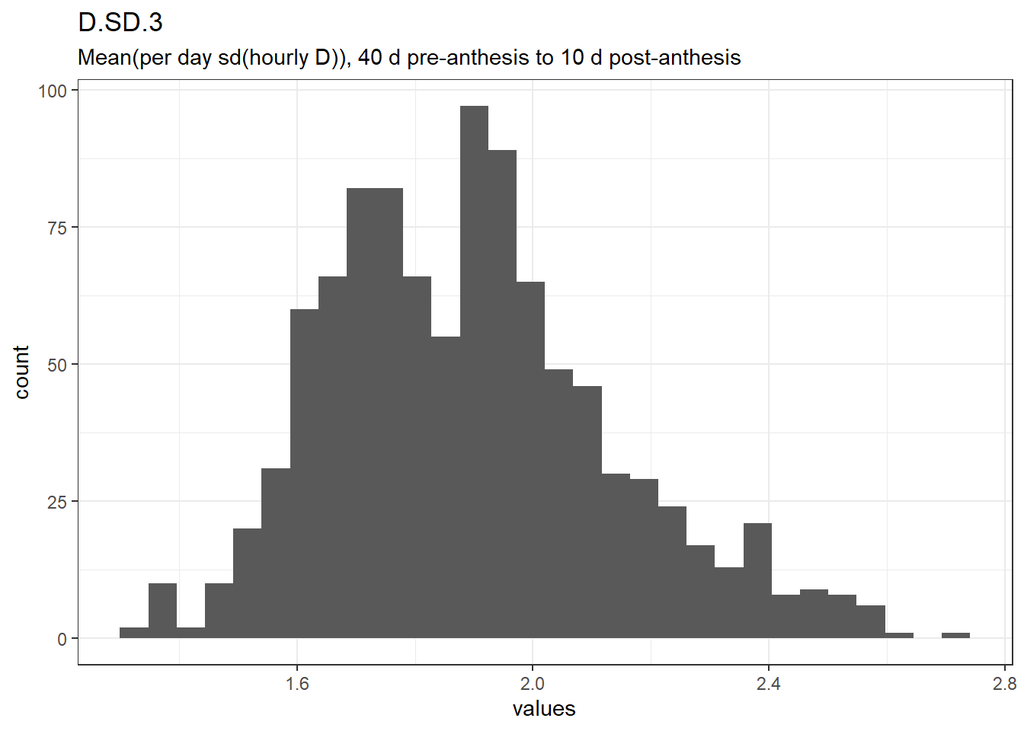

Distribution of values for D.SD.3

0 missing values.

#### Summary statistics

| name | label | data_type | n_missing | complete_rate | min | median | max | mean | sd | hist |
| --- | --- | --- | --- | --- | --- | --- | --- | --- | --- | --- |
| D.SD.3 | Mean(per day sd(hourly D)), 40 d pre-anthesis to 10 d post-anthesis | numeric | 0 | 1 | 1.3 | 1.9 | 2.7 | 1.892026 | 0.2422491 | ▂▇▇▂▁ |

### P.SD.1

Mean(per day sd(hourly P)), 60 d to 50 d pre-anthesis

#### Distribution

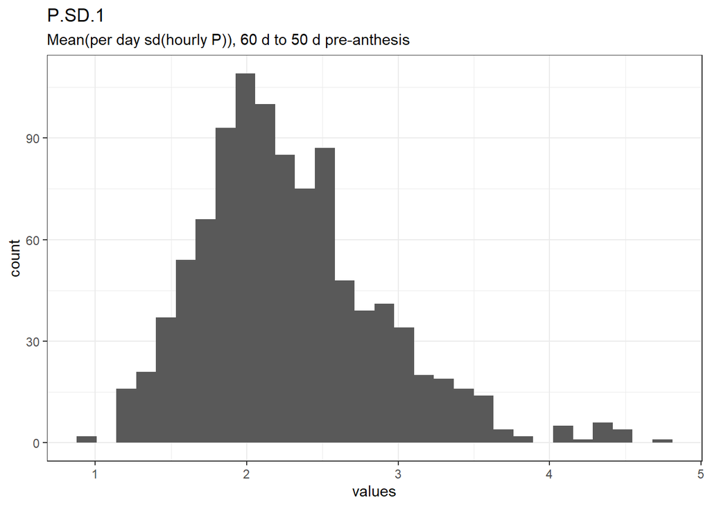

Distribution of values for P.SD.1

0 missing values.

#### Summary statistics

| name | label | data_type | n_missing | complete_rate | min | median | max | mean | sd | hist |
| --- | --- | --- | --- | --- | --- | --- | --- | --- | --- | --- |
| P.SD.1 | Mean(per day sd(hourly P)), 60 d to 50 d pre-anthesis | numeric | 0 | 1 | 0.94 | 2.2 | 4.7 | 2.282519 | 0.5995856 | ▂▇▅▁▁ |

### VPD.SD.1

Mean(per day sd(hourly VPD)), 10 d pre-anthesis to anthesis

#### Distribution

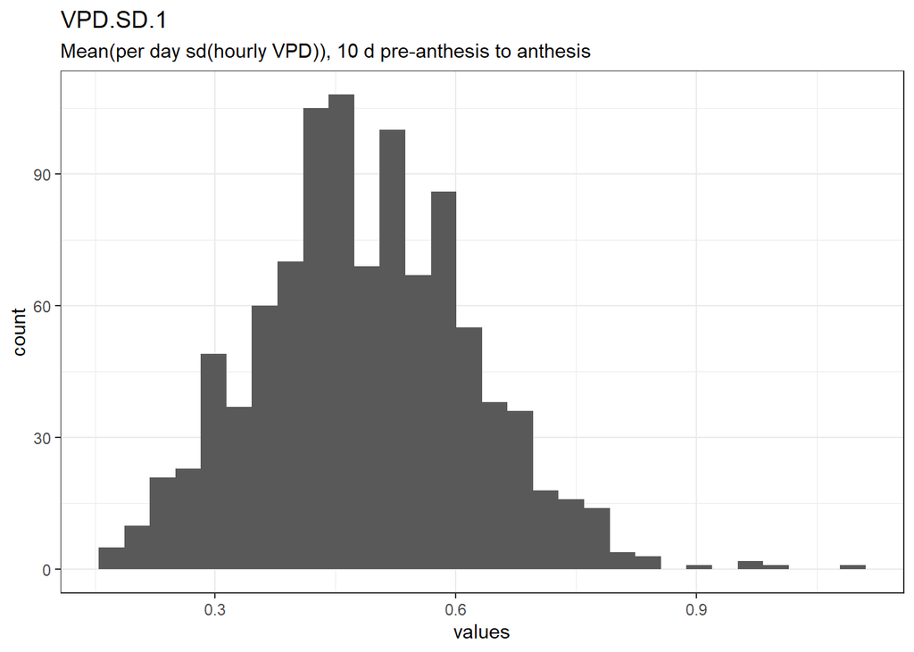

Distribution of values for VPD.SD.1

0 missing values.

#### Summary statistics

| name | label | data_type | n_missing | complete_rate | min | median | max | mean | sd | hist |
| --- | --- | --- | --- | --- | --- | --- | --- | --- | --- | --- |
| VPD.SD.1 | Mean(per day sd(hourly VPD)), 10 d pre-anthesis to anthesis | numeric | 0 | 1 | 0.17 | 0.48 | 1.1 | 0.4877175 | 0.1349036 | ▃▇▅▁▁ |

### VPD.SD.2

Mean(per day sd(hourly VPD)), 40 d pre-anthesis to anthesis

#### Distribution

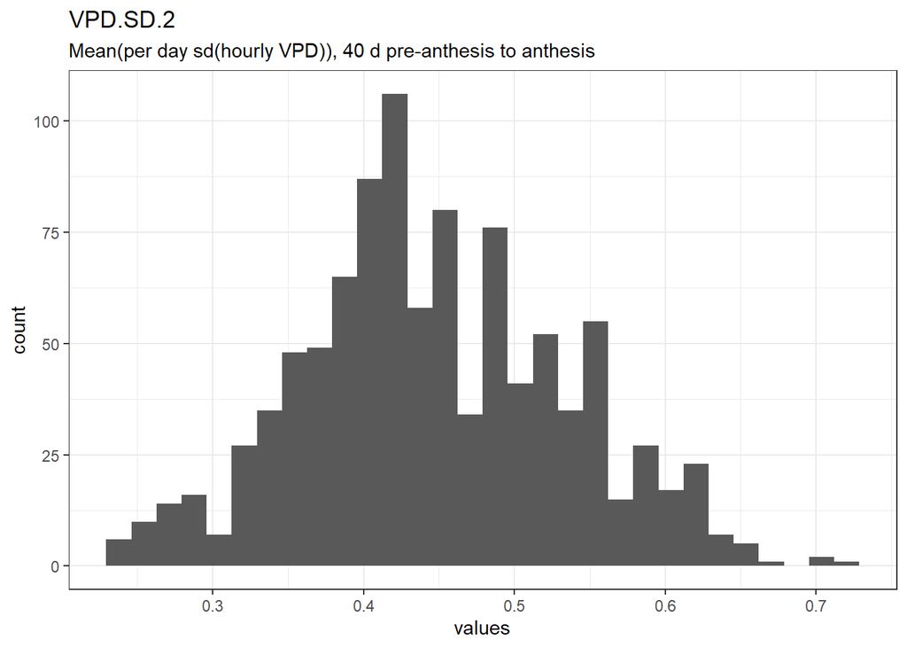

Distribution of values for VPD.SD.2

0 missing values.

#### Summary statistics

| name | label | data_type | n_missing | complete_rate | min | median | max | mean | sd | hist |
| --- | --- | --- | --- | --- | --- | --- | --- | --- | --- | --- |
| VPD.SD.2 | Mean(per day sd(hourly VPD)), 40 d pre-anthesis to anthesis | numeric | 0 | 1 | 0.24 | 0.44 | 0.72 | 0.446476 | 0.0882739 | ▂▇▇▃▁ |

### VPD.SD.3

Mean(per day sd(hourly VPD)), anthesis to 10 d post-anthesis

#### Distribution

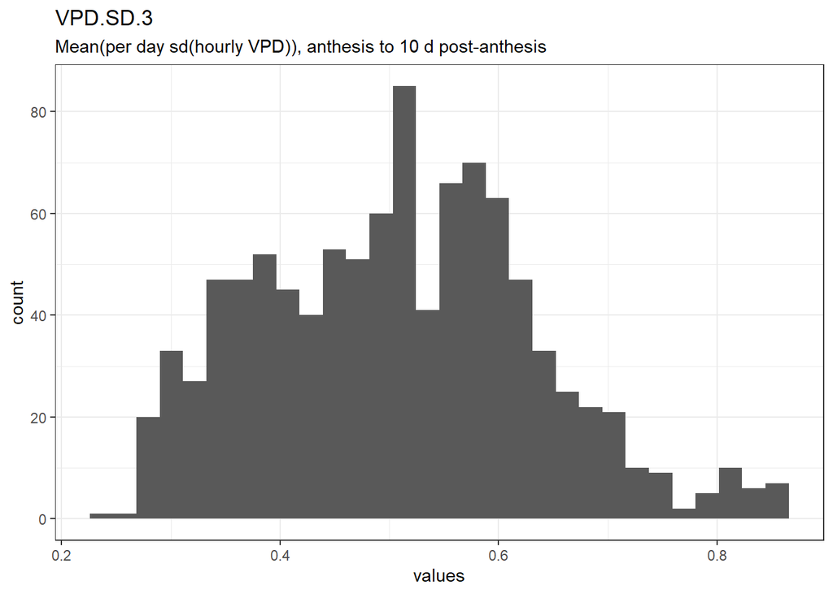

Distribution of values for VPD.SD.3

0 missing values.

#### Summary statistics

| name | label | data_type | n_missing | complete_rate | min | median | max | mean | sd | hist |
| --- | --- | --- | --- | --- | --- | --- | --- | --- | --- | --- |
| VPD.SD.3 | Mean(per day sd(hourly VPD)), anthesis to 10 d post-anthesis | numeric | 0 | 1 | 0.24 | 0.51 | 0.85 | 0.5072318 | 0.1260048 | ▃▆▇▃▁ |

### VPD.SD.4

Mean(per day sd(hourly VPD)), 10 d pre-anthesis to 10 d post-anthesis

#### Distribution

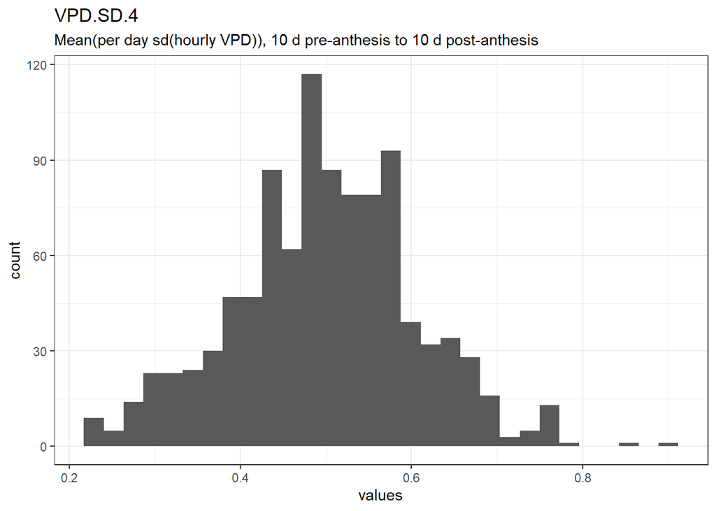

Distribution of values for VPD.SD.4

0 missing values.

#### Summary statistics

| name | label | data_type | n_missing | complete_rate | min | median | max | mean | sd | hist |
| --- | --- | --- | --- | --- | --- | --- | --- | --- | --- | --- |
| VPD.SD.4 | Mean(per day sd(hourly VPD)), 10 d pre-anthesis to 10 d post-anthesis | numeric | 0 | 1 | 0.23 | 0.5 | 0.9 | 0.4982224 | 0.1061317 | ▂▇▇▂▁ |

### RH.SD.1

Mean(per day sd(hourly RH)), 20 d pre-anthesis to anthesis

#### Distribution

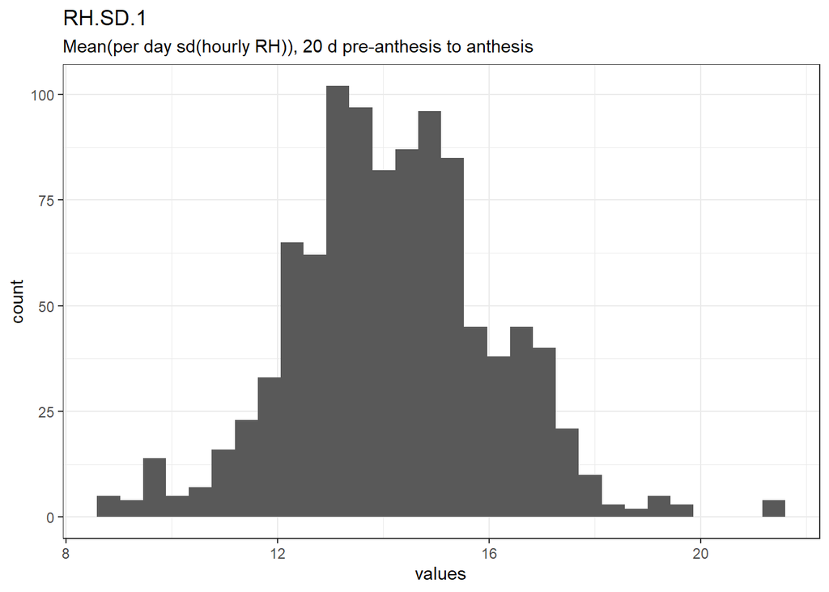

Distribution of values for RH.SD.1

0 missing values.

#### Summary statistics

| name | label | data_type | n_missing | complete_rate | min | median | max | mean | sd | hist |
| --- | --- | --- | --- | --- | --- | --- | --- | --- | --- | --- |
| RH.SD.1 | Mean(per day sd(hourly RH)), 20 d pre-anthesis to anthesis | numeric | 0 | 1 | 8.8 | 14 | 21 | 14.20398 | 1.912105 | ▁▇▇▂▁ |

### RH.SD.2

Mean(per day sd(hourly RH)), 20 d to 10 d pre-anthesis

#### Distribution

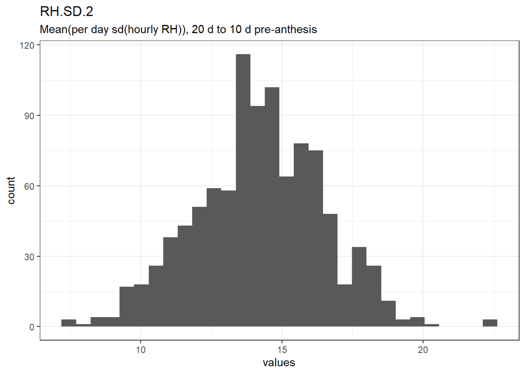

Distribution of values for RH.SD.2

0 missing values.

#### Summary statistics

| name | label | data_type | n_missing | complete_rate | min | median | max | mean | sd | hist |
| --- | --- | --- | --- | --- | --- | --- | --- | --- | --- | --- |
| RH.SD.2 | Mean(per day sd(hourly RH)), 20 d to 10 d pre-anthesis | numeric | 0 | 1 | 7.5 | 14 | 22 | 14.19143 | 2.27213 | ▁▅▇▂▁ |

### TDD.SD.1

Mean(per day sd(hourly TDD)), 30 d pre-anthesis to anthesis

#### Distribution

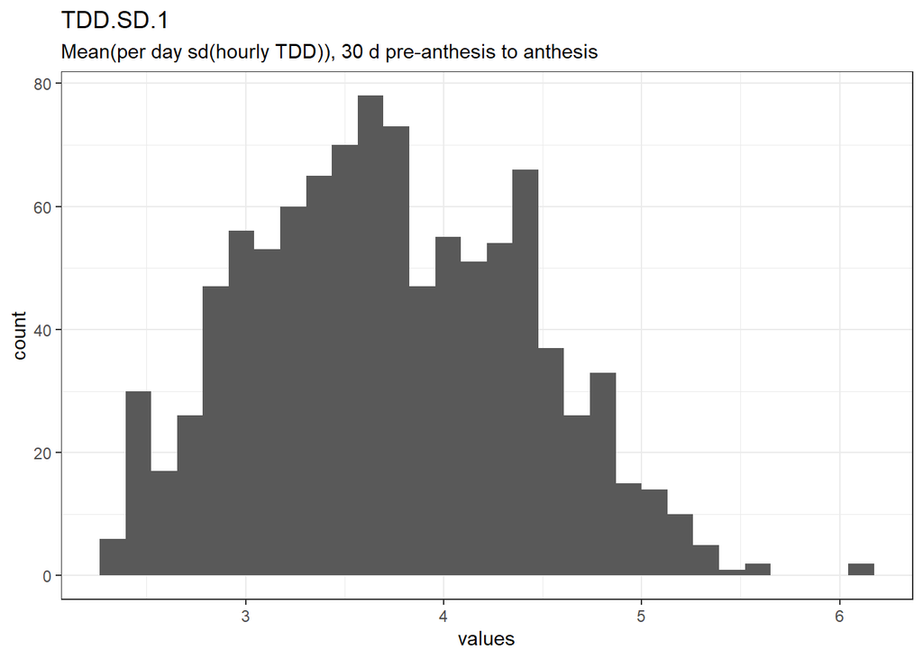

Distribution of values for TDD.SD.1

0 missing values.

#### Summary statistics

| name | label | data_type | n_missing | complete_rate | min | median | max | mean | sd | hist |
| --- | --- | --- | --- | --- | --- | --- | --- | --- | --- | --- |
| TDD.SD.1 | Mean(per day sd(hourly TDD)), 30 d pre-anthesis to anthesis | numeric | 0 | 1 | 2.3 | 3.7 | 6.1 | 3.730456 | 0.6885693 | ▃▇▆▂▁ |

### TDD.SD.2

Mean(per day sd(hourly TDD)), 40 d pre-anthesis to anthesis

#### Distribution

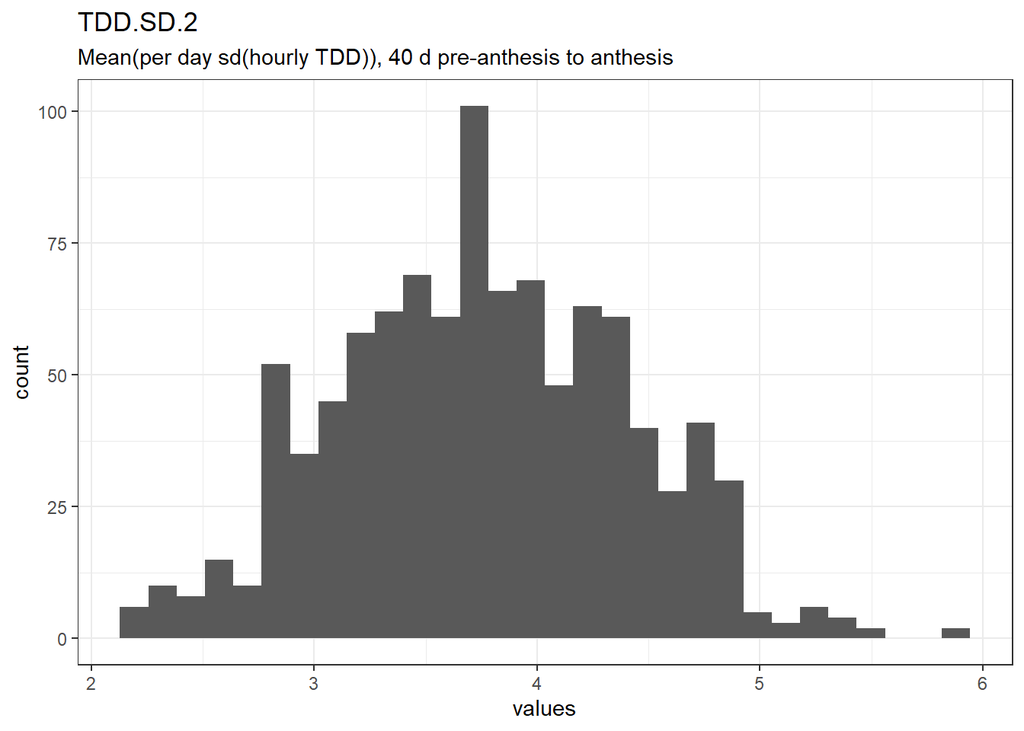

Distribution of values for TDD.SD.2

0 missing values.

#### Summary statistics

| name | label | data_type | n_missing | complete_rate | min | median | max | mean | sd | hist |
| --- | --- | --- | --- | --- | --- | --- | --- | --- | --- | --- |
| TDD.SD.2 | Mean(per day sd(hourly TDD)), 40 d pre-anthesis to anthesis | numeric | 0 | 1 | 2.2 | 3.7 | 5.9 | 3.757471 | 0.6496284 | ▂▇▇▃▁ |

### TDD.SD.3

Mean(per day sd(hourly TDD)), anthesis to 10 d post-anthesis

#### Distribution

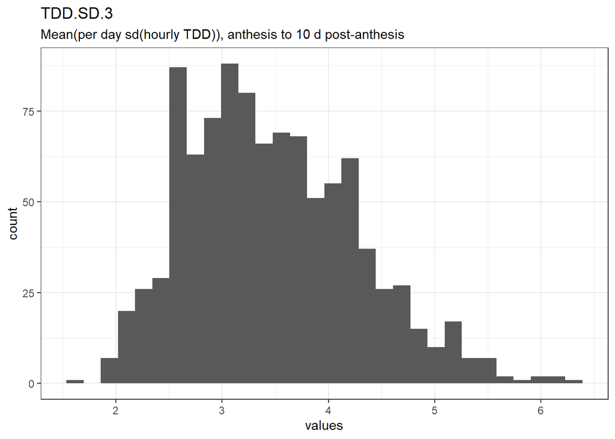

Distribution of values for TDD.SD.3

0 missing values.

#### Summary statistics

| name | label | data_type | n_missing | complete_rate | min | median | max | mean | sd | hist |
| --- | --- | --- | --- | --- | --- | --- | --- | --- | --- | --- |
| TDD.SD.3 | Mean(per day sd(hourly TDD)), anthesis to 10 d post-anthesis | numeric | 0 | 1 | 1.6 | 3.4 | 6.3 | 3.474297 | 0.8067007 | ▂▇▆▂▁ |

### TDD.SD.4

Mean(per day sd(hourly TDD)), 20 d pre-anthesis to 10 d post-anthesis

#### Distribution

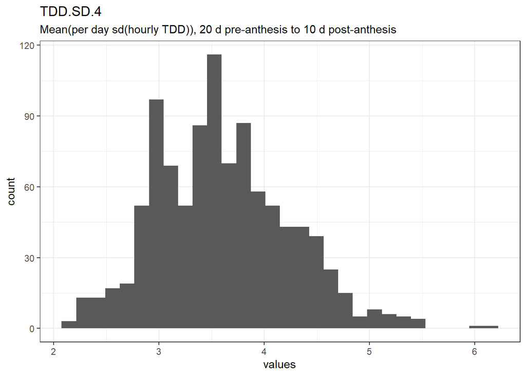

Distribution of values for TDD.SD.4

0 missing values.

#### Summary statistics

| name | label | data_type | n_missing | complete_rate | min | median | max | mean | sd | hist |
| --- | --- | --- | --- | --- | --- | --- | --- | --- | --- | --- |
| TDD.SD.4 | Mean(per day sd(hourly TDD)), 20 d pre-anthesis to 10 d post-anthesis | numeric | 0 | 1 | 2.1 | 3.5 | 6.2 | 3.600561 | 0.6355838 | ▂▇▆▁▁ |

### MT7

Mean daily minimum T (°C), 7 d pre-anthesis to anthesis

#### Distribution

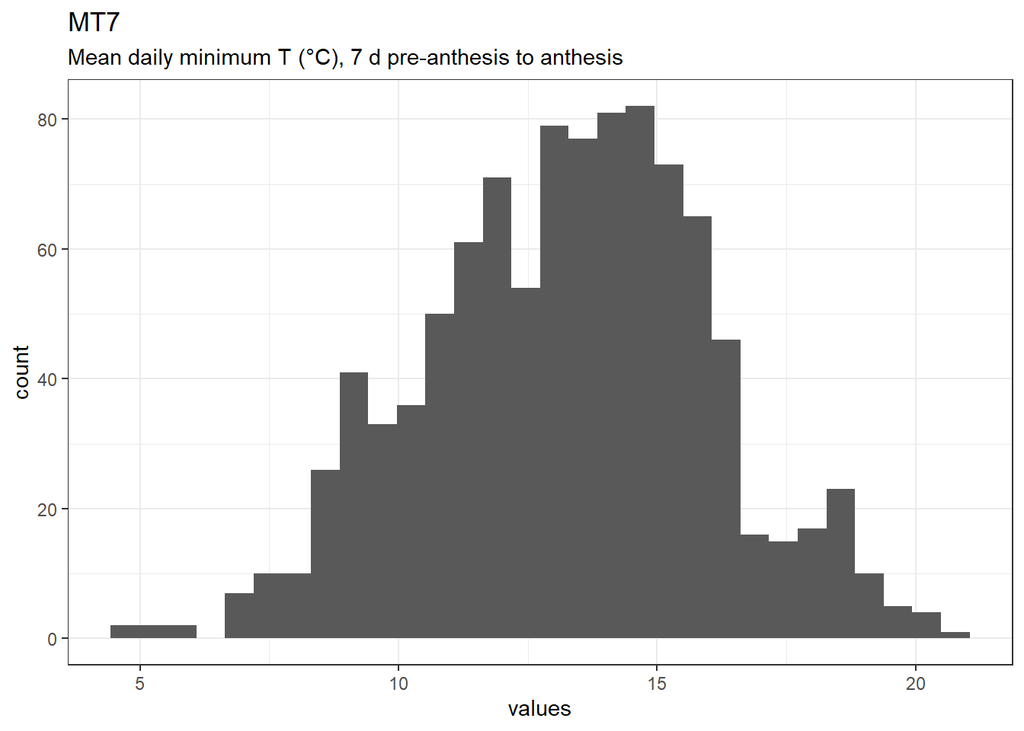

Distribution of values for MT7

0 missing values.

#### Summary statistics

| name | label | data_type | n_missing | complete_rate | min | median | max | mean | sd | hist |
| --- | --- | --- | --- | --- | --- | --- | --- | --- | --- | --- |
| MT7 | Mean daily minimum T (°C), 7 d pre-anthesis to anthesis | numeric | 0 | 1 | 4.7 | 13 | 21 | 13.24222 | 2.747601 | ▁▃▇▆▁ |

### T157

No. hr (T $\geq$ 15°C), 7 d pre-anthesis to anthesis

#### Distribution

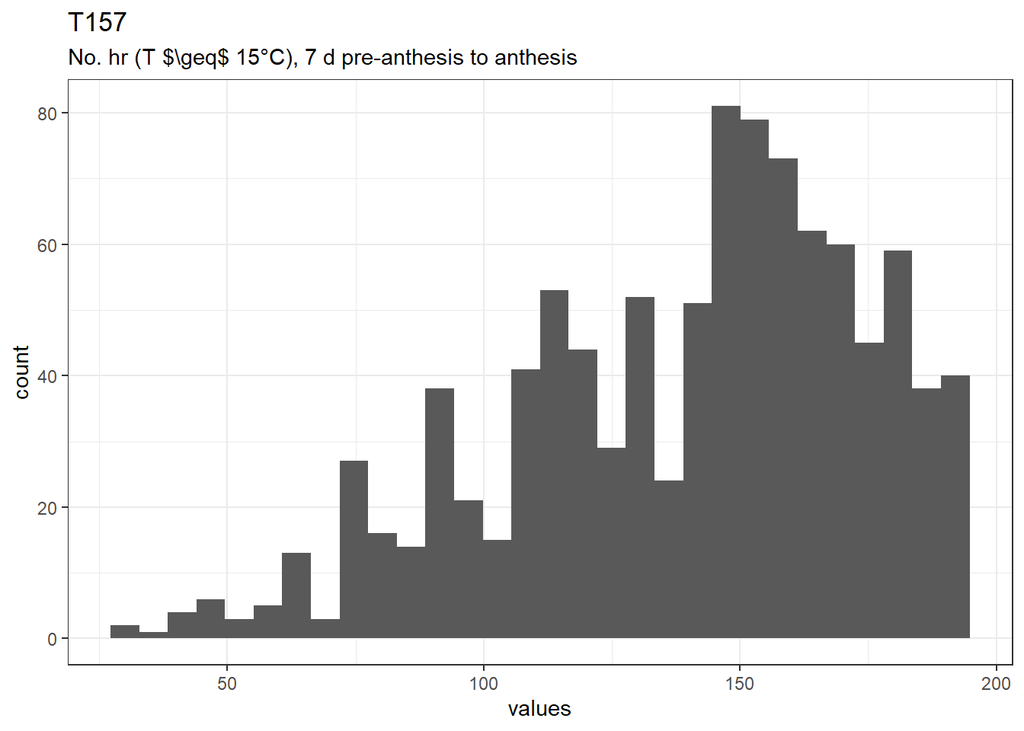

Distribution of values for T157

0 missing values.

#### Summary statistics

| name | label | data_type | n_missing | complete_rate | min | median | max | mean | sd | hist |
| --- | --- | --- | --- | --- | --- | --- | --- | --- | --- | --- |
| T157 | No. hr (T $\geq$ 15°C), 7 d pre-anthesis to anthesis | numeric | 0 | 1 | 30 | 147 | 192 | 139.7017 | 35.04233 | ▁▂▅▇▇ |

### T15307

No. hr (15°C $\leq$ T $\leq$ 30°C), 7 d pre-anthesis to anthesis

#### Distribution

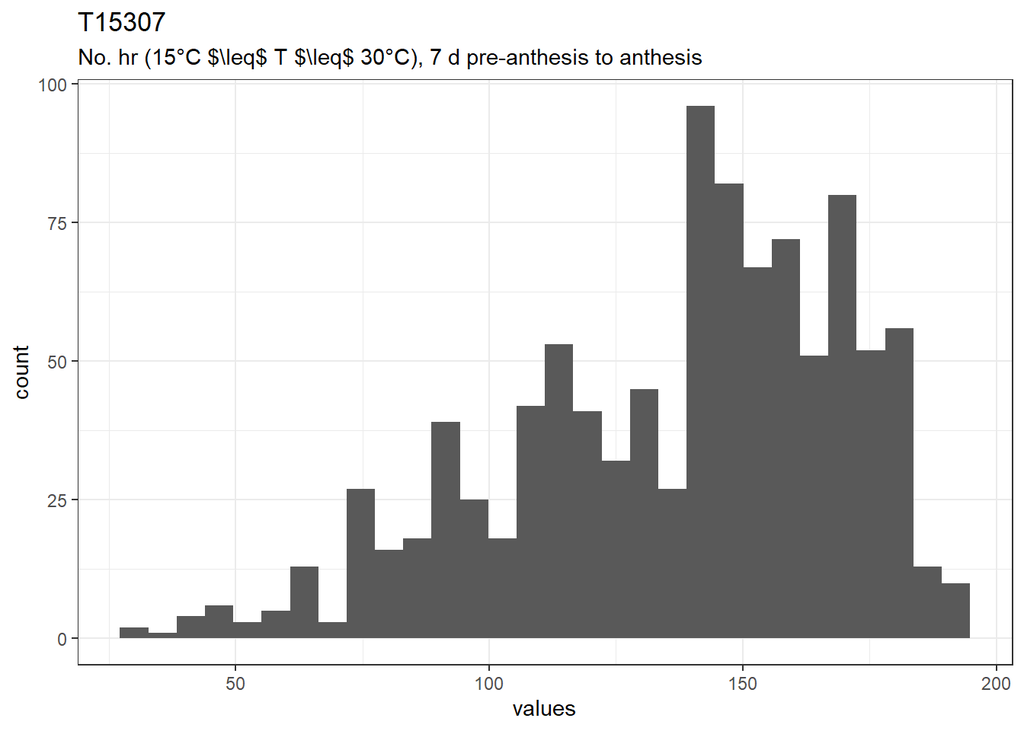

Distribution of values for T15307

0 missing values.

#### Summary statistics

| name | label | data_type | n_missing | complete_rate | min | median | max | mean | sd | hist |
| --- | --- | --- | --- | --- | --- | --- | --- | --- | --- | --- |
| T15307 | No. hr (15°C $\leq$ T $\leq$ 30°C), 7 d pre-anthesis to anthesis | numeric | 0 | 1 | 30 | 144 | 192 | 136.8338 | 33.4429 | ▁▂▅▇▆ |

### RH7

Mean daily RH (%), 7 d pre-anthesis to anthesis

#### Distribution

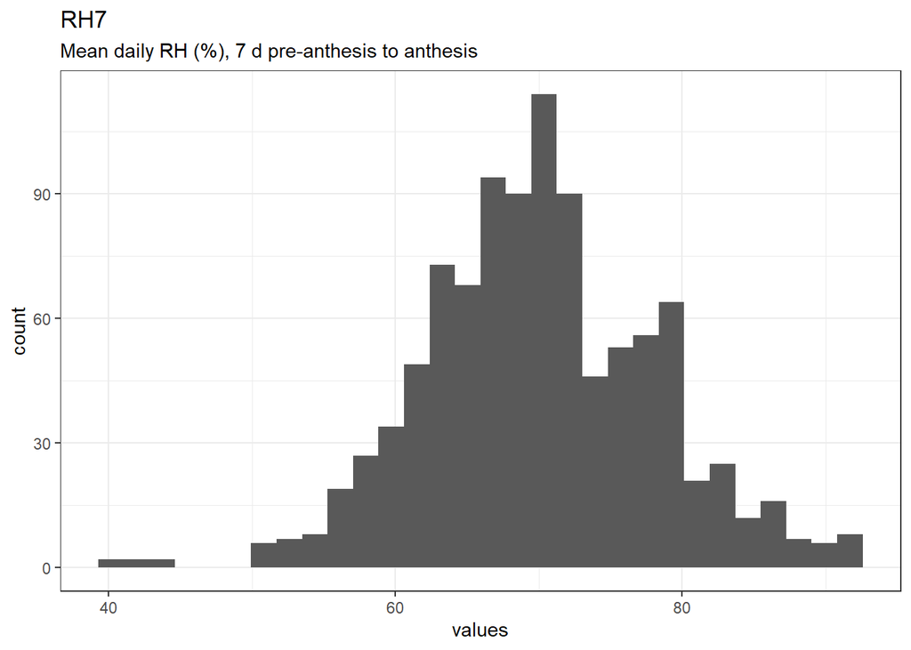

Distribution of values for RH7

0 missing values.

#### Summary statistics

| name | label | data_type | n_missing | complete_rate | min | median | max | mean | sd | hist |
| --- | --- | --- | --- | --- | --- | --- | --- | --- | --- | --- |
| RH7 | Mean daily RH (%), 7 d pre-anthesis to anthesis | numeric | 0 | 1 | 40 | 70 | 92 | 69.97822 | 8.096852 | ▁▂▇▆▂ |

### RH907

No. hr (RH $\geq$ 90%), 7 d pre-anthesis to anthesis

#### Distribution

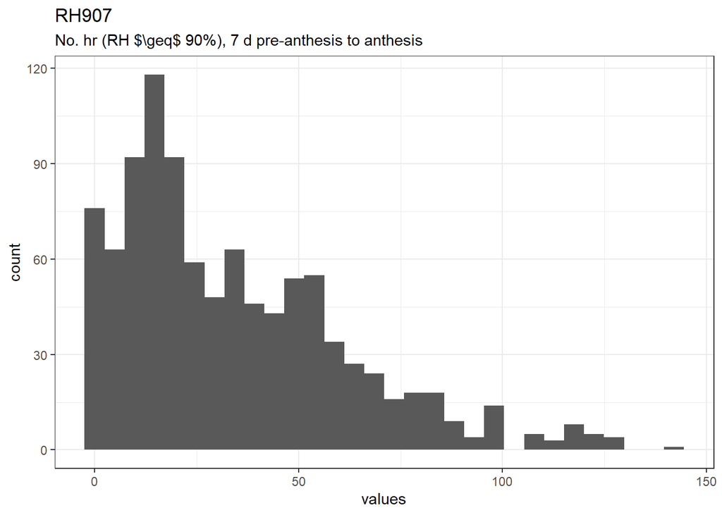

Distribution of values for RH907

0 missing values.

#### Summary statistics

| name | label | data_type | n_missing | complete_rate | min | median | max | mean | sd | hist |
| --- | --- | --- | --- | --- | --- | --- | --- | --- | --- | --- |
| RH907 | No. hr (RH $\geq$ 90%), 7 d pre-anthesis to anthesis | numeric | 0 | 1 | 0 | 26 | 142 | 34.26326 | 27.73583 | ▇▅▂▁▁ |

### TRH907

No. hr (15°C $\leq$ T $\leq$ 30°C & RH $\geq$ 90%), 7 d pre-anthesis to anthesis

#### Distribution

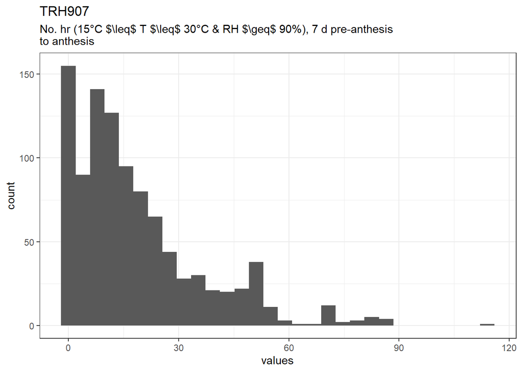

Distribution of values for TRH907

0 missing values.

#### Summary statistics

| name | label | data_type | n_missing | complete_rate | min | median | max | mean | sd | hist |
| --- | --- | --- | --- | --- | --- | --- | --- | --- | --- | --- |
| TRH907 | No. hr (15°C $\leq$ T $\leq$ 30°C & RH $\geq$ 90%), 7 d pre-anthesis to anthesis | numeric | 0 | 1 | 0 | 13 | 114 | 18.31932 | 17.85769 | ▇▂▁▁▁ |

### TRH807

No. hr (15°C $\leq$ T $\leq$ 30°C & RH $\geq$ 80%), 7 d pre-anthesis to anthesis

#### Distribution

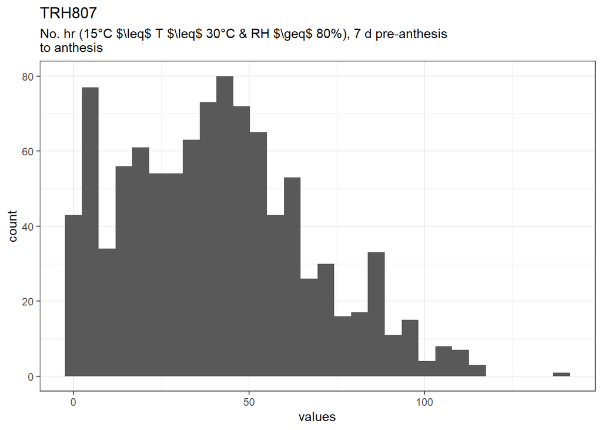

Distribution of values for TRH807

0 missing values.

#### Summary statistics

| name | label | data_type | n_missing | complete_rate | min | median | max | mean | sd | hist |
| --- | --- | --- | --- | --- | --- | --- | --- | --- | --- | --- |
| TRH807 | No. hr (15°C $\leq$ T $\leq$ 30°C & RH $\geq$ 80%), 7 d pre-anthesis to anthesis | numeric | 0 | 1 | 0 | 39 | 139 | 40.8018 | 26.34964 | ▇▇▃▂▁ |

### MT10

Daily minimum T (°C), anthesis to 10 d post-anthesis

#### Distribution

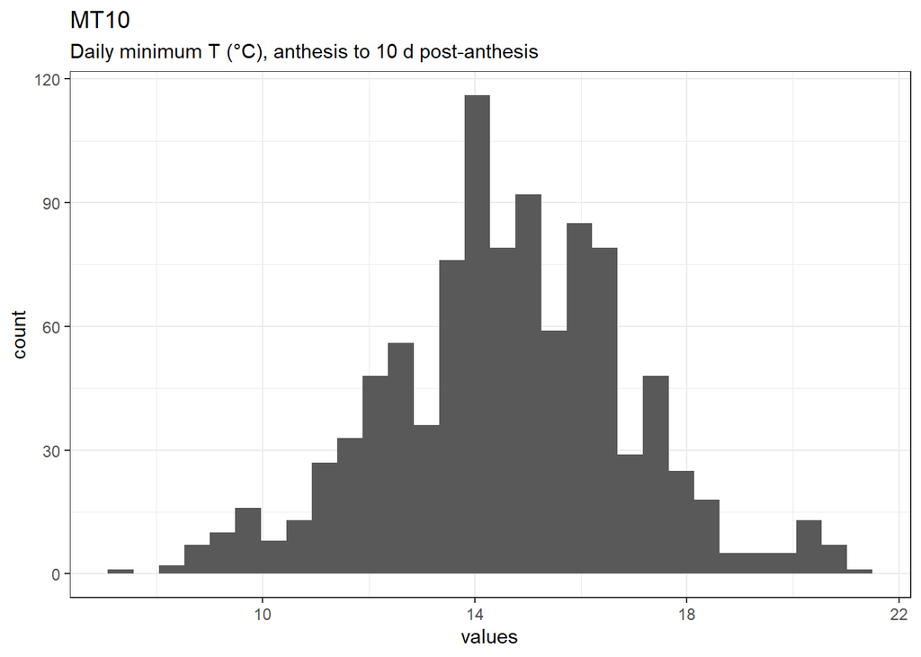

Distribution of values for MT10

0 missing values.

#### Summary statistics

| name | label | data_type | n_missing | complete_rate | min | median | max | mean | sd | hist |
| --- | --- | --- | --- | --- | --- | --- | --- | --- | --- | --- |
| MT10 | Daily minimum T (°C), anthesis to 10 d post-anthesis | numeric | 0 | 1 | 7.3 | 15 | 21 | 14.60082 | 2.311702 | ▁▃▇▅▁ |

### T1510

No. hr (T $\geq$ 15°C), anthesis to 10 d post-anthesis

#### Distribution

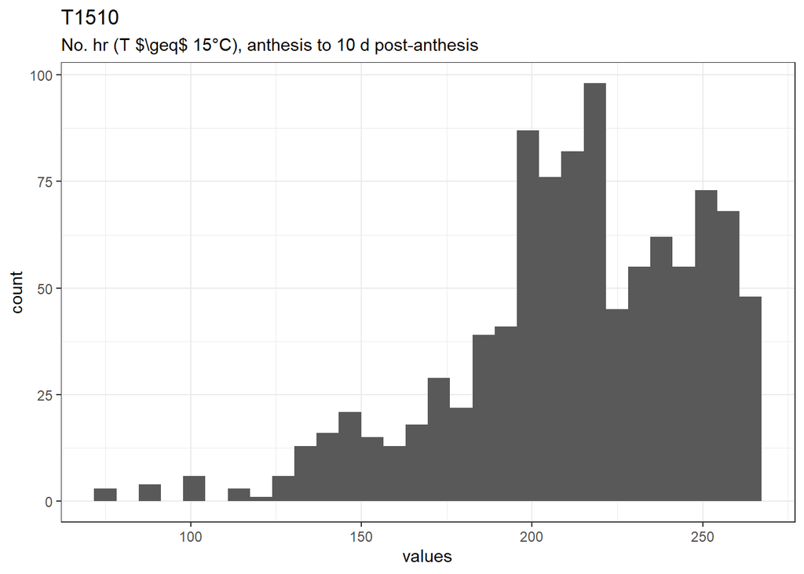

Distribution of values for T1510

0 missing values.

#### Summary statistics

| name | label | data_type | n_missing | complete_rate | min | median | max | mean | sd | hist |
| --- | --- | --- | --- | --- | --- | --- | --- | --- | --- | --- |
| T1510 | No. hr (T $\geq$ 15°C), anthesis to 10 d post-anthesis | numeric | 0 | 1 | 75 | 216 | 264 | 212.4785 | 35.77722 | ▁▁▂▇▇ |

### T153010

No. hr (15°C $\leq$ T $\leq$ 30°C), anthesis to 10 d post-anthesis

#### Distribution

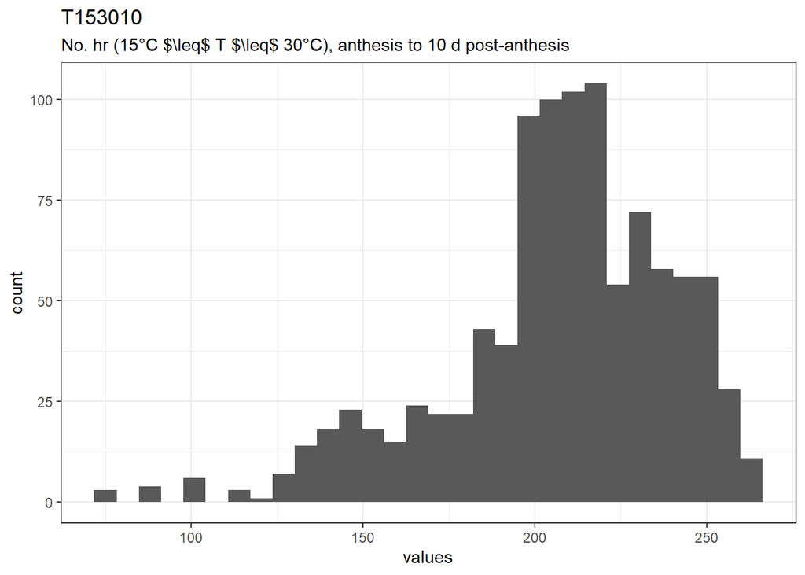

Distribution of values for T153010

0 missing values.

#### Summary statistics

| name | label | data_type | n_missing | complete_rate | min | median | max | mean | sd | hist |
| --- | --- | --- | --- | --- | --- | --- | --- | --- | --- | --- |
| T153010 | No. hr (15°C $\leq$ T $\leq$ 30°C), anthesis to 10 d post-anthesis | numeric | 0 | 1 | 75 | 210 | 263 | 206.5656 | 33.03583 | ▁▁▂▇▅ |

### RH10

Mean daily RH (%), anthesis to 10 d post-anthesis; same as RH.A.2

#### Distribution

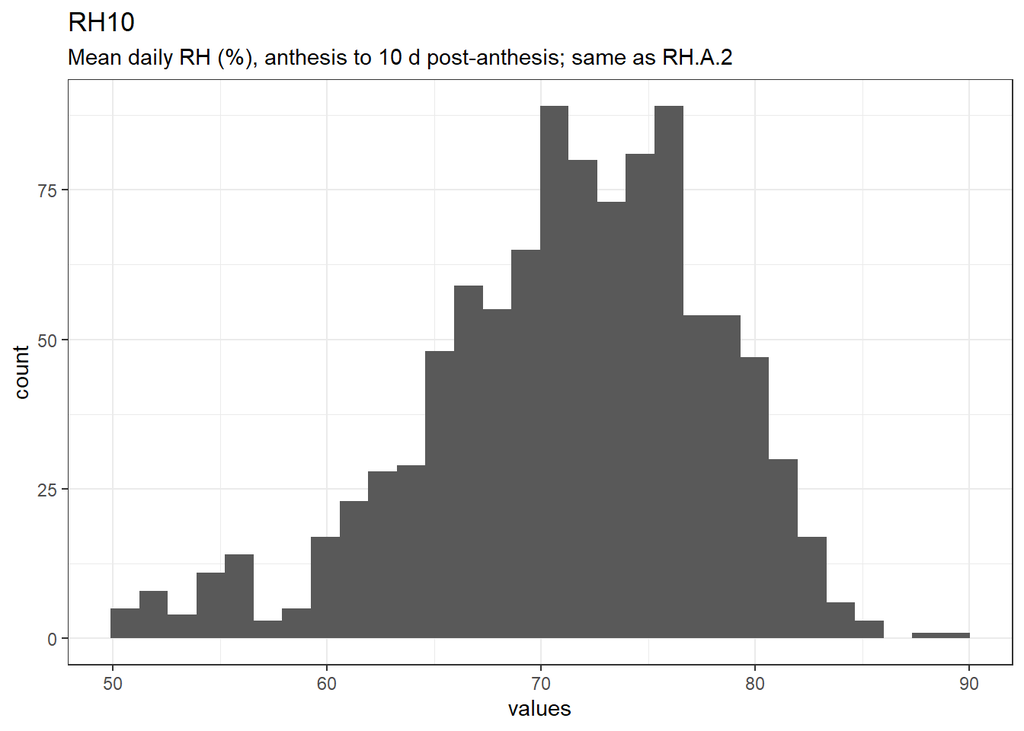

Distribution of values for RH10

0 missing values.

#### Summary statistics

| name | label | data_type | n_missing | complete_rate | min | median | max | mean | sd | hist |
| --- | --- | --- | --- | --- | --- | --- | --- | --- | --- | --- |
| RH10 | Mean daily RH (%), anthesis to 10 d post-anthesis; same as RH.A.2 | numeric | 0 | 1 | 51 | 72 | 89 | 71.30815 | 6.697947 | ▁▃▇▇▁ |

### RH9010

No. hr (RH $\geq$ 90%), anthesis to 10 d post-anthesis

#### Distribution

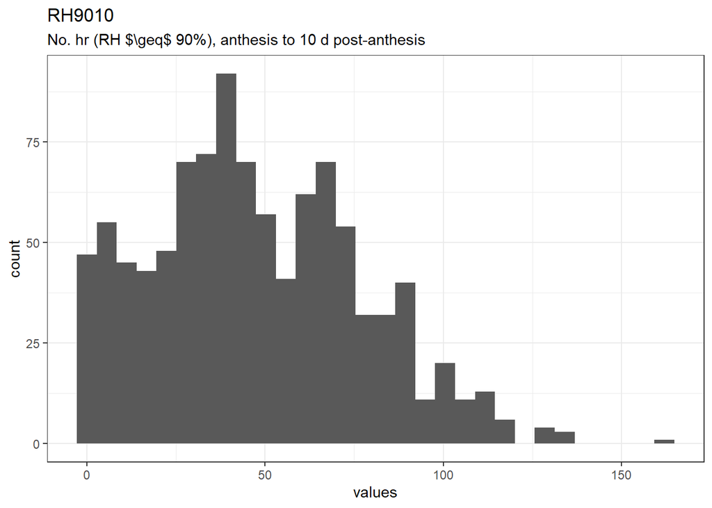

Distribution of values for RH9010

0 missing values.

#### Summary statistics

| name | label | data_type | n_missing | complete_rate | min | median | max | mean | sd | hist |
| --- | --- | --- | --- | --- | --- | --- | --- | --- | --- | --- |
| RH9010 | No. hr (RH $\geq$ 90%), anthesis to 10 d post-anthesis | numeric | 0 | 1 | 0 | 43 | 162 | 47.49149 | 29.50513 | ▇▇▅▁▁ |

### RH8010

No. hr (RH $\geq$ 80%), anthesis to 10 d post-anthesis

#### Distribution

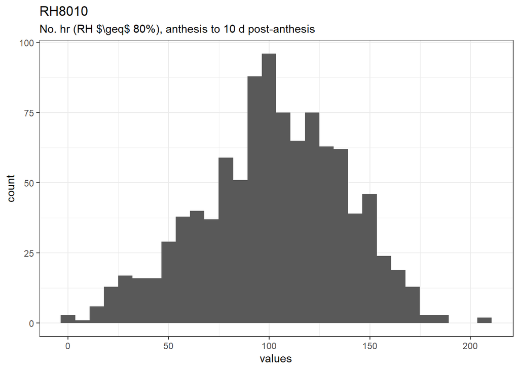

Distribution of values for RH8010

0 missing values.

#### Summary statistics

| name | label | data_type | n_missing | complete_rate | min | median | max | mean | sd | hist |
| --- | --- | --- | --- | --- | --- | --- | --- | --- | --- | --- |
| RH8010 | No. hr (RH $\geq$ 80%), anthesis to 10 d post-anthesis | numeric | 0 | 1 | 0 | 103 | 207 | 101.8649 | 35.84154 | ▁▃▇▅▁ |

### TRH9010

No. hr (15°C $\leq$ T $\leq$ 30°C & RH $\geq$ 90%), anthesis to 10 d post-anthesis

#### Distribution

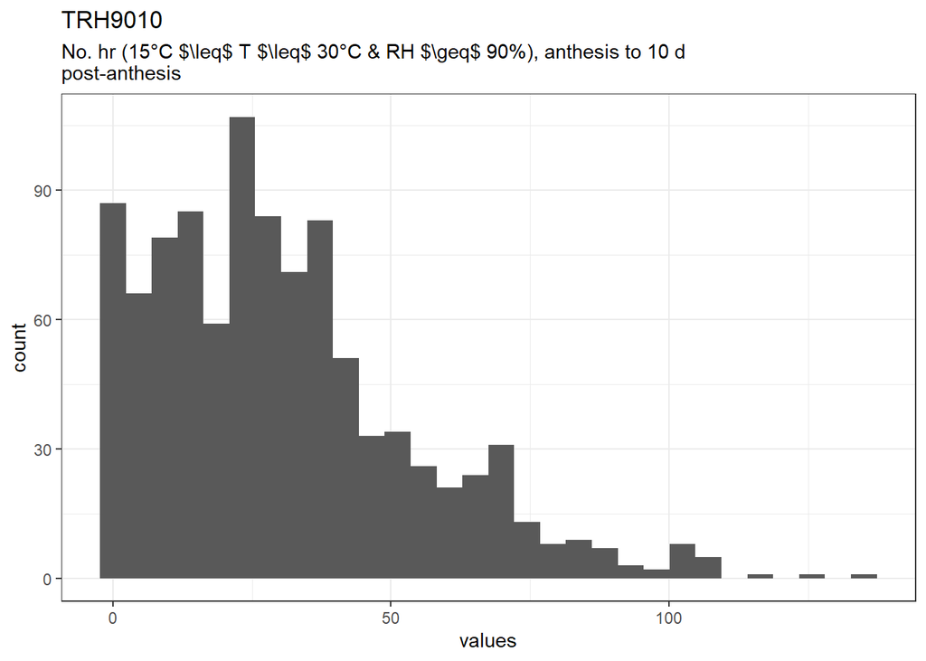

Distribution of values for TRH9010

0 missing values.

#### Summary statistics

| name | label | data_type | n_missing | complete_rate | min | median | max | mean | sd | hist |
| --- | --- | --- | --- | --- | --- | --- | --- | --- | --- | --- |
| TRH9010 | No. hr (15°C $\leq$ T $\leq$ 30°C & RH $\geq$ 90%), anthesis to 10 d post-anthesis | numeric | 0 | 1 | 0 | 27 | 135 | 30.50651 | 23.66021 | ▇▅▂▁▁ |

### TRH8010

No. hr (15°C $\leq$ T $\leq$ 30°C & RH $\geq$ 80%), anthesis to 10 d post-anthesis

#### Distribution

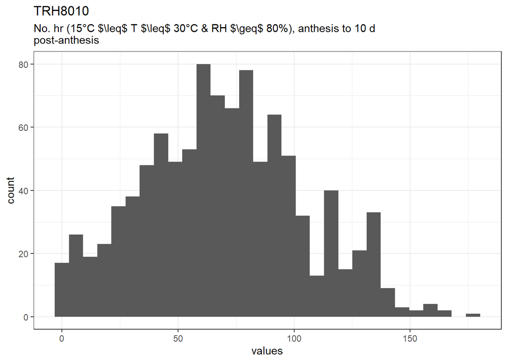

Distribution of values for TRH8010

0 missing values.

#### Summary statistics

| name | label | data_type | n_missing | complete_rate | min | median | max | mean | sd | hist |
| --- | --- | --- | --- | --- | --- | --- | --- | --- | --- | --- |
| TRH8010 | No. hr (15°C $\leq$ T $\leq$ 30°C & RH $\geq$ 80%), anthesis to 10 d post-anthesis | numeric | 0 | 1 | 0 | 69 | 177 | 69.48949 | 34.62513 | ▃▇▇▃▁ |

### INT3

The product T15307 $\times$ TRH9010

#### Distribution

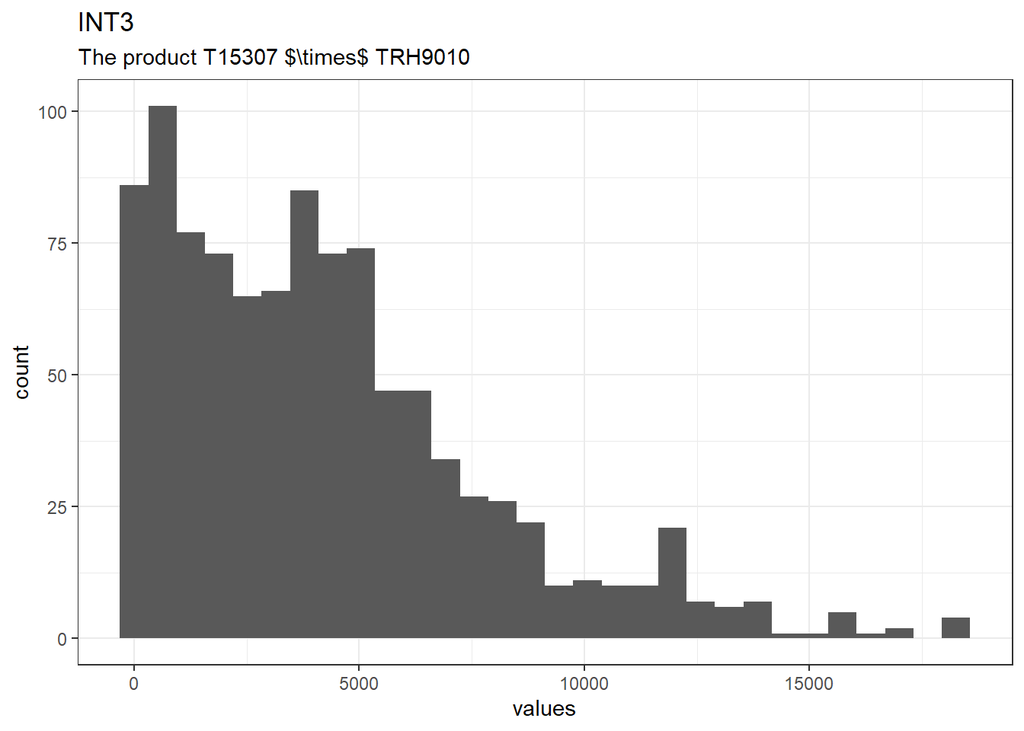

Distribution of values for INT3

0 missing values.

#### Summary statistics

| name | label | data_type | n_missing | complete_rate | min | median | max | mean | sd | hist |
| --- | --- | --- | --- | --- | --- | --- | --- | --- | --- | --- |
| INT3 | The product T15307 $\times$ TRH9010 | numeric | 0 | 1 | 0 | 3660 | 18250 | 4255.531 | 3556.041 | ▇▅▂▁▁ |

### VPD.A.PRE5.12H

Mean overnight VPD, 5 d pre-anthesis to anthesis

#### Distribution

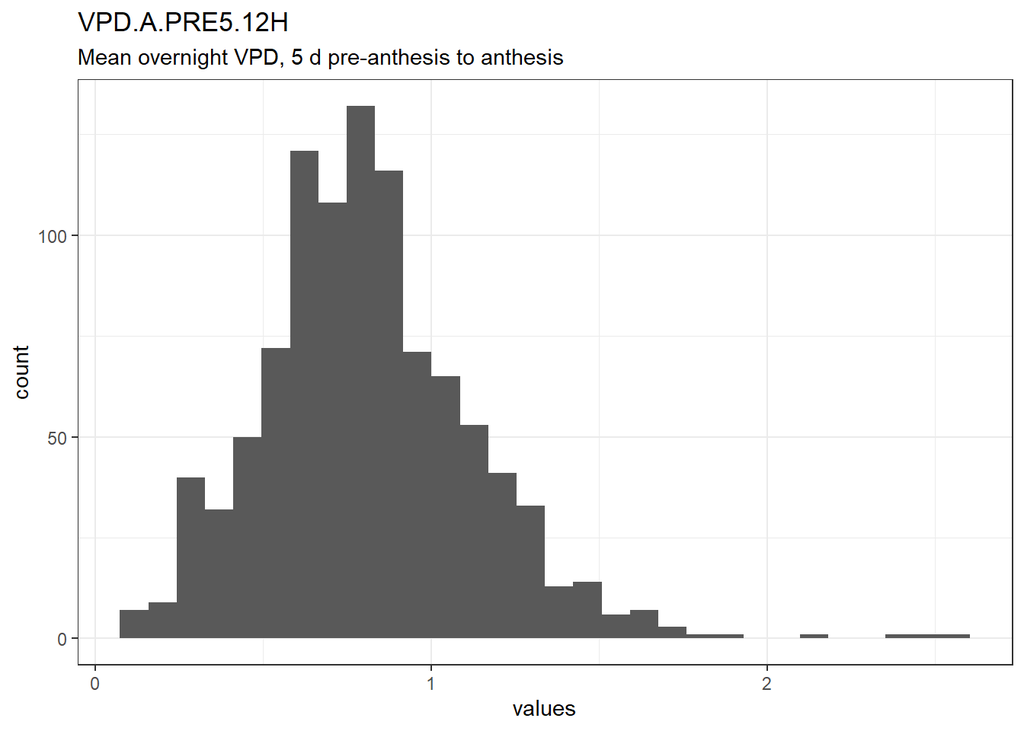

Distribution of values for VPD.A.PRE5.12H

0 missing values.

#### Summary statistics

| name | label | data_type | n_missing | complete_rate | min | median | max | mean | sd | hist |
| --- | --- | --- | --- | --- | --- | --- | --- | --- | --- | --- |
| VPD.A.PRE5.12H | Mean overnight VPD, 5 d pre-anthesis to anthesis | numeric | 0 | 1 | 0.12 | 0.79 | 2.6 | 0.8103918 | 0.3155073 | ▃▇▂▁▁ |

### VPD.L20.PRE5.12H

No. hr (overnight VPD $\leq$ 0.20 kPa), 5 d pre-anthesis to anthesis

#### Distribution

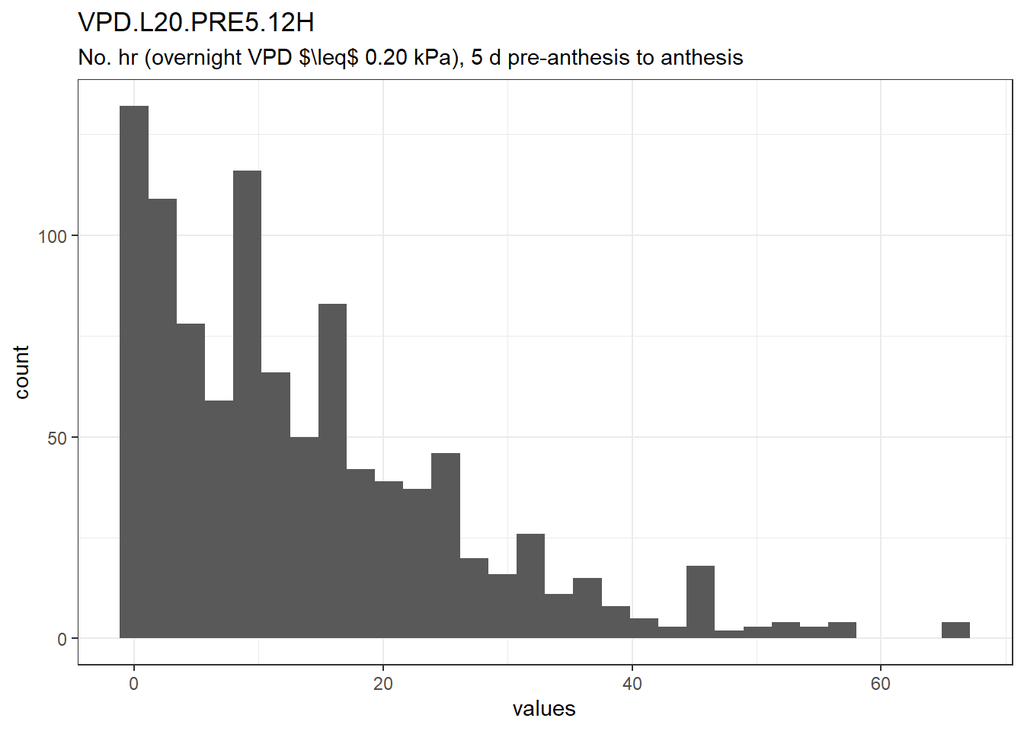

Distribution of values for VPD.L20.PRE5.12H

0 missing values.

#### Summary statistics

| name | label | data_type | n_missing | complete_rate | min | median | max | mean | sd | hist |
| --- | --- | --- | --- | --- | --- | --- | --- | --- | --- | --- |
| VPD.L20.PRE5.12H | No. hr (overnight VPD $\leq$ 0.20 kPa), 5 d pre-anthesis to anthesis | numeric | 0 | 1 | 0 | 11 | 66 | 13.76877 | 12.52235 | ▇▃▁▁▁ |

### VPD.L45.PRE5.12H

No. hr (overnight VPD $\leq$ 0.45 kPa), 5 d pre-anthesis to anthesis

#### Distribution

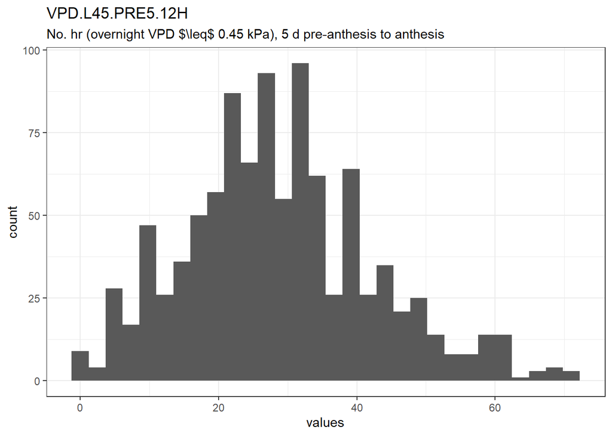

Distribution of values for VPD.L45.PRE5.12H

0 missing values.

#### Summary statistics

| name | label | data_type | n_missing | complete_rate | min | median | max | mean | sd | hist |
| --- | --- | --- | --- | --- | --- | --- | --- | --- | --- | --- |
| VPD.L45.PRE5.12H | No. hr (overnight VPD $\leq$ 0.45 kPa), 5 d pre-anthesis to anthesis | numeric | 0 | 1 | 0 | 28 | 71 | 28.75475 | 13.57806 | ▃▇▇▂▁ |

### VPD.A.PRE7.12H

Mean overnight VPD, 7 d pre-anthesis to anthesis

#### Distribution

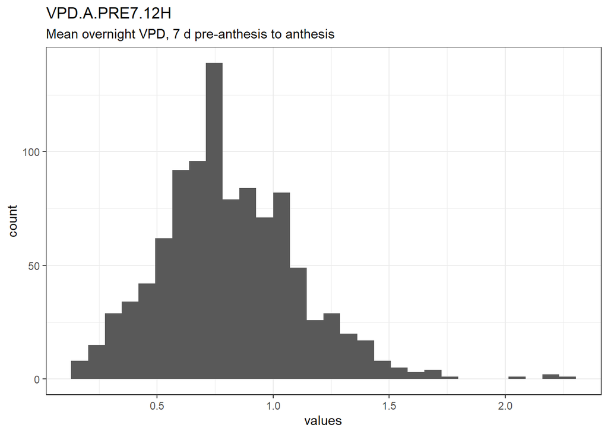

Distribution of values for VPD.A.PRE7.12H

0 missing values.

#### Summary statistics

| name | label | data_type | n_missing | complete_rate | min | median | max | mean | sd | hist |
| --- | --- | --- | --- | --- | --- | --- | --- | --- | --- | --- |
| VPD.A.PRE7.12H | Mean overnight VPD, 7 d pre-anthesis to anthesis | numeric | 0 | 1 | 0.17 | 0.77 | 2.3 | 0.8112554 | 0.2972565 | ▃▇▃▁▁ |

### VPD.L20.PRE7.12H

No. hr (overnight VPD $\leq$ 0.20 kPa), 7 d pre-anthesis to anthesis

#### Distribution

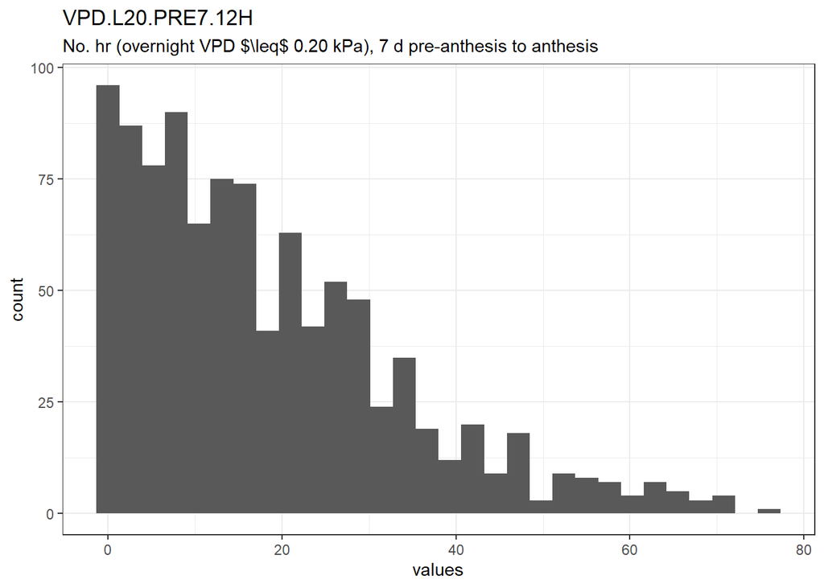

Distribution of values for VPD.L20.PRE7.12H

0 missing values.

#### Summary statistics

| name | label | data_type | n_missing | complete_rate | min | median | max | mean | sd | hist |
| --- | --- | --- | --- | --- | --- | --- | --- | --- | --- | --- |
| VPD.L20.PRE7.12H | No. hr (overnight VPD $\leq$ 0.20 kPa), 7 d pre-anthesis to anthesis | numeric | 0 | 1 | 0 | 15 | 76 | 18.3023 | 15.46904 | ▇▅▂▁▁ |

### VPD.L45.PRE7.12H

No. hr (overnight VPD $\leq$ 0.45 kPa), 7 d pre-anthesis to anthesis

#### Distribution

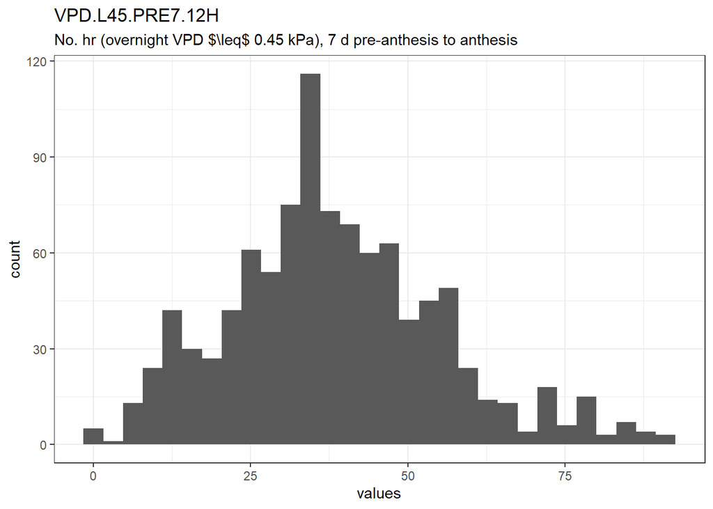

Distribution of values for VPD.L45.PRE7.12H

0 missing values.

#### Summary statistics

| name | label | data_type | n_missing | complete_rate | min | median | max | mean | sd | hist |
| --- | --- | --- | --- | --- | --- | --- | --- | --- | --- | --- |
| VPD.L45.PRE7.12H | No. hr (overnight VPD $\leq$ 0.45 kPa), 7 d pre-anthesis to anthesis | numeric | 0 | 1 | 0 | 37 | 91 | 38.33133 | 17.08476 | ▂▇▇▂▁ |

### VPD.A.PRE10.12H

Mean overnight VPD, 10 d pre-anthesis to anthesis

#### Distribution

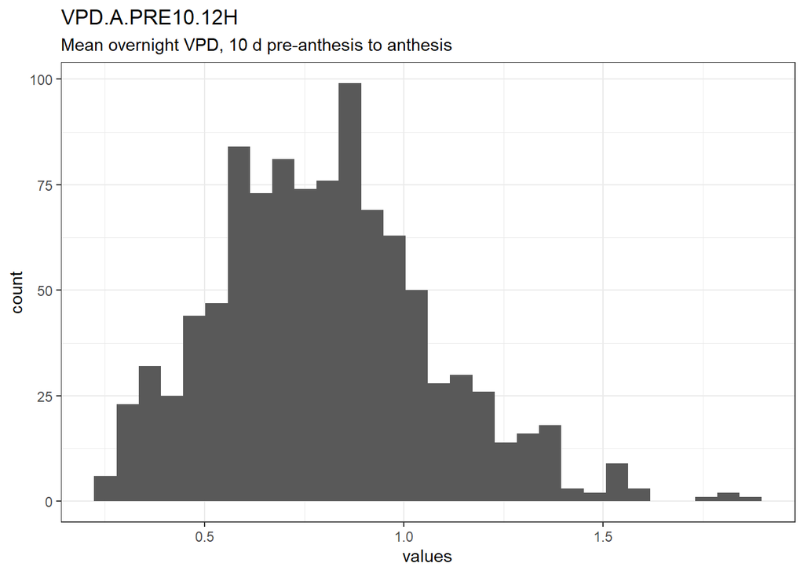

Distribution of values for VPD.A.PRE10.12H

0 missing values.

#### Summary statistics

| name | label | data_type | n_missing | complete_rate | min | median | max | mean | sd | hist |
| --- | --- | --- | --- | --- | --- | --- | --- | --- | --- | --- |
| VPD.A.PRE10.12H | Mean overnight VPD, 10 d pre-anthesis to anthesis | numeric | 0 | 1 | 0.25 | 0.8 | 1.9 | 0.8010824 | 0.2720151 | ▃▇▅▁▁ |

### VPD.L20.PRE10.12H

No. hr (overnight VPD $\leq$ 0.20 kPa), 10 d pre-anthesis to anthesis

#### Distribution

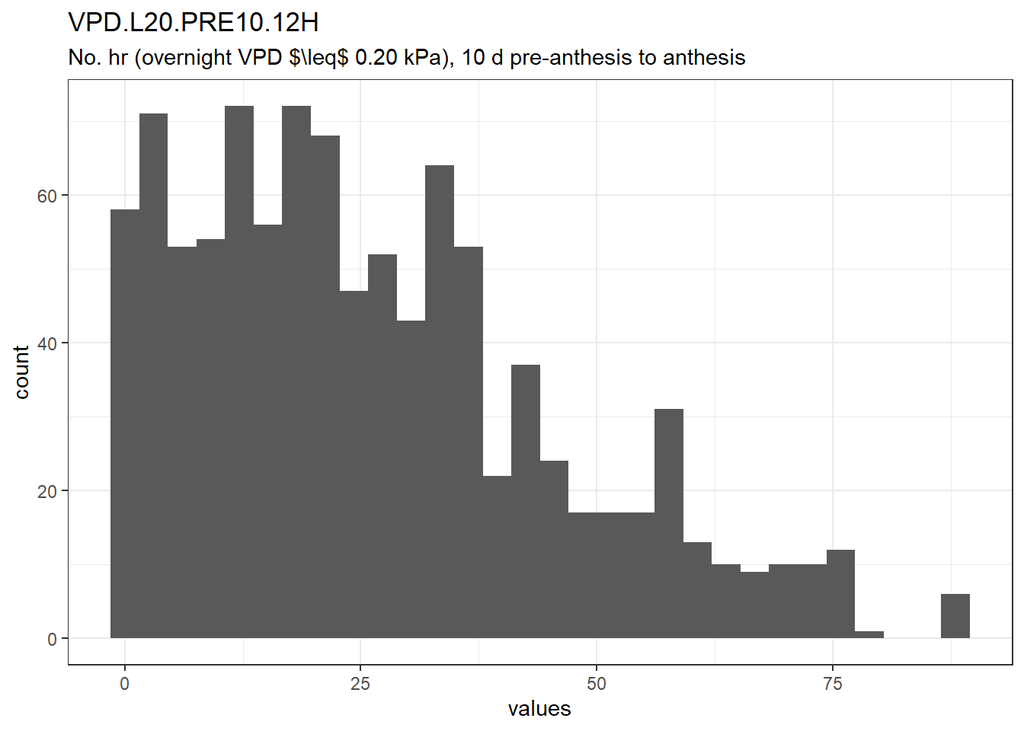

Distribution of values for VPD.L20.PRE10.12H

0 missing values.

#### Summary statistics

| name | label | data_type | n_missing | complete_rate | min | median | max | mean | sd | hist |
| --- | --- | --- | --- | --- | --- | --- | --- | --- | --- | --- |
| VPD.L20.PRE10.12H | No. hr (overnight VPD $\leq$ 0.20 kPa), 10 d pre-anthesis to anthesis | numeric | 0 | 1 | 0 | 22 | 88 | 26.33433 | 19.60523 | ▇▇▃▂▁ |

### VPD.L45.PRE10.12H

No. hr (overnight VPD $\leq$ 0.45 kPa), 10 d pre-anthesis to anthesis

#### Distribution

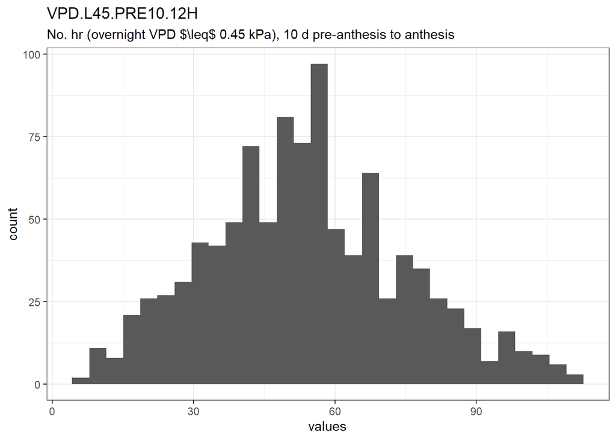

Distribution of values for VPD.L45.PRE10.12H

0 missing values.

#### Summary statistics

| name | label | data_type | n_missing | complete_rate | min | median | max | mean | sd | hist |
| --- | --- | --- | --- | --- | --- | --- | --- | --- | --- | --- |
| VPD.L45.PRE10.12H | No. hr (overnight VPD $\leq$ 0.45 kPa), 10 d pre-anthesis to anthesis | numeric | 0 | 1 | 6 | 53 | 111 | 54.01802 | 21.20162 | ▂▆▇▃▁ |

### VPD.A.PRE14.12H

Mean overnight VPD, 14 d pre-anthesis to anthesis

#### Distribution

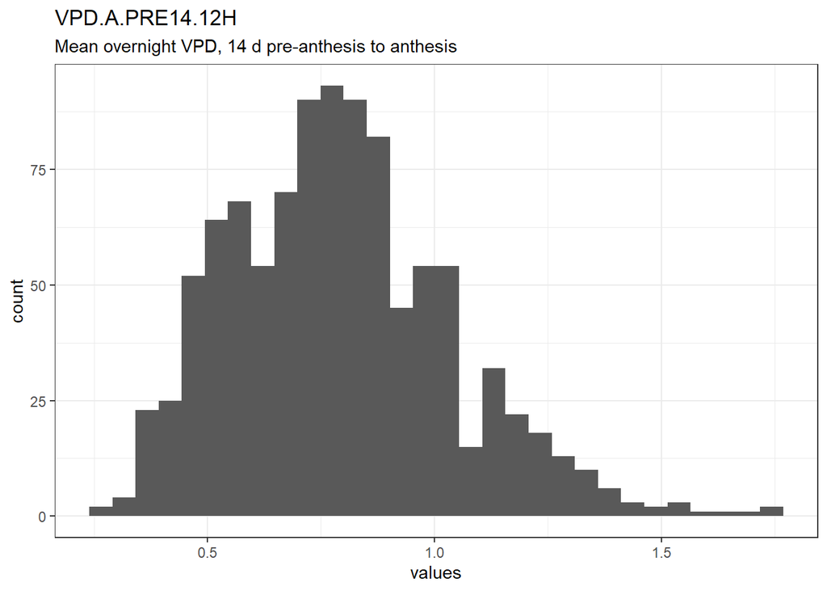

Distribution of values for VPD.A.PRE14.12H

0 missing values.

#### Summary statistics

| name | label | data_type | n_missing | complete_rate | min | median | max | mean | sd | hist |
| --- | --- | --- | --- | --- | --- | --- | --- | --- | --- | --- |
| VPD.A.PRE14.12H | Mean overnight VPD, 14 d pre-anthesis to anthesis | numeric | 0 | 1 | 0.27 | 0.77 | 1.7 | 0.7910981 | 0.2448714 | ▃▇▅▁▁ |

### VPD.L20.PRE14.12H

No. hr (overnight VPD $\leq$ 0.20 kPa), 14 d pre-anthesis to anthesis

#### Distribution

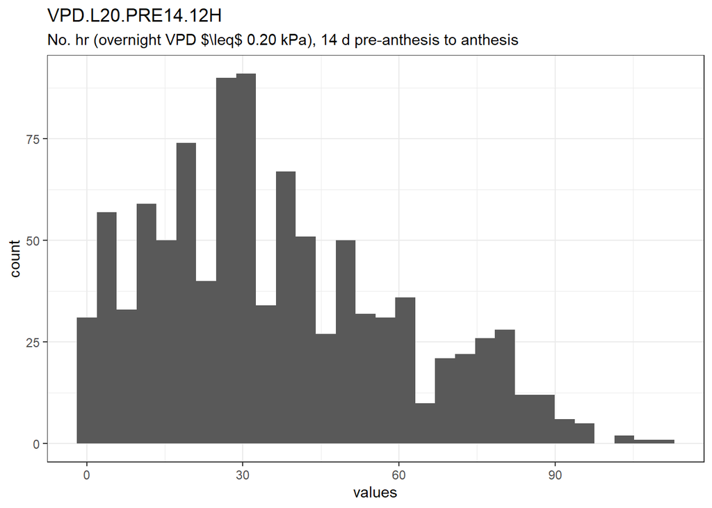

Distribution of values for VPD.L20.PRE14.12H

0 missing values.

#### Summary statistics

| name | label | data_type | n_missing | complete_rate | min | median | max | mean | sd | hist |
| --- | --- | --- | --- | --- | --- | --- | --- | --- | --- | --- |
| VPD.L20.PRE14.12H | No. hr (overnight VPD $\leq$ 0.20 kPa), 14 d pre-anthesis to anthesis | numeric | 0 | 1 | 0 | 32 | 111 | 36.28929 | 23.63779 | ▇▇▅▂▁ |

### VPD.L45.PRE14.12H

No. hr (overnight VPD $\leq$ 0.45 kPa), 14 d pre-anthesis to anthesis

#### Distribution

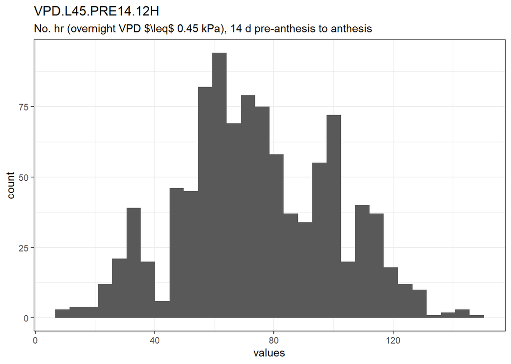

Distribution of values for VPD.L45.PRE14.12H

0 missing values.

#### Summary statistics

| name | label | data_type | n_missing | complete_rate | min | median | max | mean | sd | hist |
| --- | --- | --- | --- | --- | --- | --- | --- | --- | --- | --- |
| VPD.L45.PRE14.12H | No. hr (overnight VPD $\leq$ 0.45 kPa), 14 d pre-anthesis to anthesis | numeric | 0 | 1 | 9 | 72 | 148 | 74.38438 | 25.6895 | ▂▆▇▆▁ |

### VPD.A.PRE15.12H

Mean overnight VPD, 15 d pre-anthesis to anthesis

#### Distribution

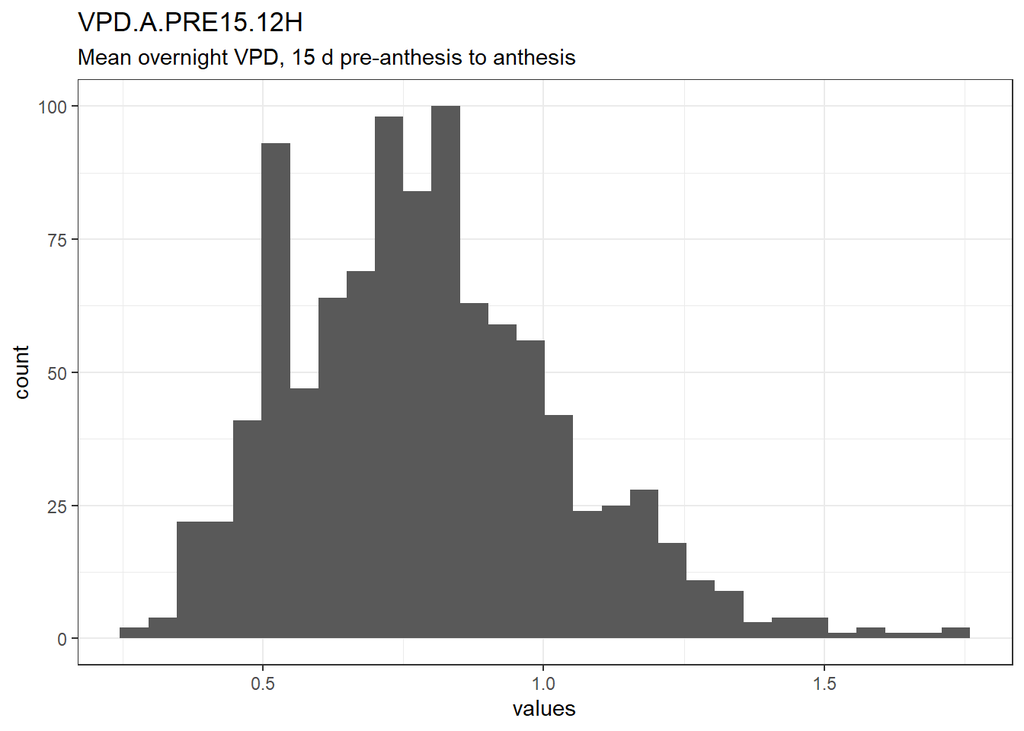

Distribution of values for VPD.A.PRE15.12H

0 missing values.

#### Summary statistics

| name | label | data_type | n_missing | complete_rate | min | median | max | mean | sd | hist |
| --- | --- | --- | --- | --- | --- | --- | --- | --- | --- | --- |
| VPD.A.PRE15.12H | Mean overnight VPD, 15 d pre-anthesis to anthesis | numeric | 0 | 1 | 0.27 | 0.78 | 1.7 | 0.7909107 | 0.2400585 | ▃▇▅▁▁ |